# Supervised Learning : Exploring Parametric Accelerated Failure Time Models for Estimating Lifetimes in Survival Data

## 1.5. Data Exploration

### 1.5.1 Exploratory Data Analysis

1. The estimated baseline survival plot indicated a 50% survival rate at N_Days=3358.
2. Bivariate analysis identified individual predictors with potential association to the event status based on visual inspection.
   - Higher values for the following numeric predictors are associated with Status=True:
     - Age
     - Bilirubin
     - Copper
     - Alk_Phos
     - SGOT
     - Tryglicerides
     - Prothrombin
   - Higher counts for the following object predictors are associated with better differentiation between Status=True and Status=False:
     - Drug
     - Sex
     - Ascites
     - Hepatomegaly
     - Spiders
     - Edema
     - Stage_1.0
     - Stage_2.0
     - Stage_3.0
     - Stage_4.0
3. Bivariate analysis identified individual predictors with potential association to the survival time based on visual inspection.
   - Higher values for the following numeric predictors are positively associated with N_Days:
     - Albumin
     - Platelets
   - Levels for the following object predictors are associated with differences in N_Days between Status=True and Status=False:
     - Drug
     - Sex
     - Ascites
     - Hepatomegaly
     - Spiders
     - Edema
     - Stage_1.0
     - Stage_2.0
     - Stage_3.0
     - Stage_4.0

```python
##################################
# Formulating a complete dataframe
# from the training subset for EDA
##################################
cirrhosis_survival_y_train_cleaned.reset_index(drop=True, inplace=True)
cirrhosis_survival_train_EDA = pd.concat([cirrhosis_survival_y_train_cleaned,
                                          cirrhosis_survival_X_train_preprocessed],
                                         axis=1)
cirrhosis_survival_train_EDA.head()
```

|  | Status | N_Days | Age | Bilirubin | Cholesterol | Albumin | Copper | Alk_Phos | SGOT | Tryglicerides | ... | Drug | Sex | Ascites | Hepatomegaly | Spiders | Edema | Stage_1.0 | Stage_2.0 | Stage_3.0 | Stage_4.0 |
| --- | --- | --- | --- | --- | --- | --- | --- | --- | --- | --- | --- | --- | --- | --- | --- | --- | --- | --- | --- | --- | --- |
| 0 | False | 2475 | -1.342097 | 0.863802 | 0.886087 | -0.451884 | -0.972098 | 0.140990 | 0.104609 | 0.155130 | ... | 1 | 1 | 0 | 0 | 0 | 0 | False | True | False | False |
| 1 | False | 877 | -1.470901 | 0.516350 | 1.554523 | 0.827618 | 0.467579 | -0.705337 | 0.301441 | 1.275222 | ... | 1 | 0 | 0 | 0 | 0 | 0 | False | False | True | False |
| 2 | False | 3050 | -0.239814 | -0.625875 | 0.293280 | 0.646582 | -0.241205 | -0.848544 | 0.275723 | -1.684460 | ... | 1 | 1 | 0 | 0 | 0 | 0 | False | True | False | False |
| 3 | True | 110 | -0.052733 | 0.559437 | -1.534283 | 0.354473 | -0.284113 | -0.014525 | 0.162878 | -0.189139 | ... | 0 | 1 | 1 | 1 | 1 | 1 | False | False | False | True |
| 4 | True | 3839 | -0.795010 | 1.142068 | -0.108933 | -0.272913 | 0.618030 | 2.071847 | 1.434674 | -0.212684 | ... | 0 | 1 | 0 | 1 | 0 | 0 | False | True | False | False |

5 rows × 22 columns

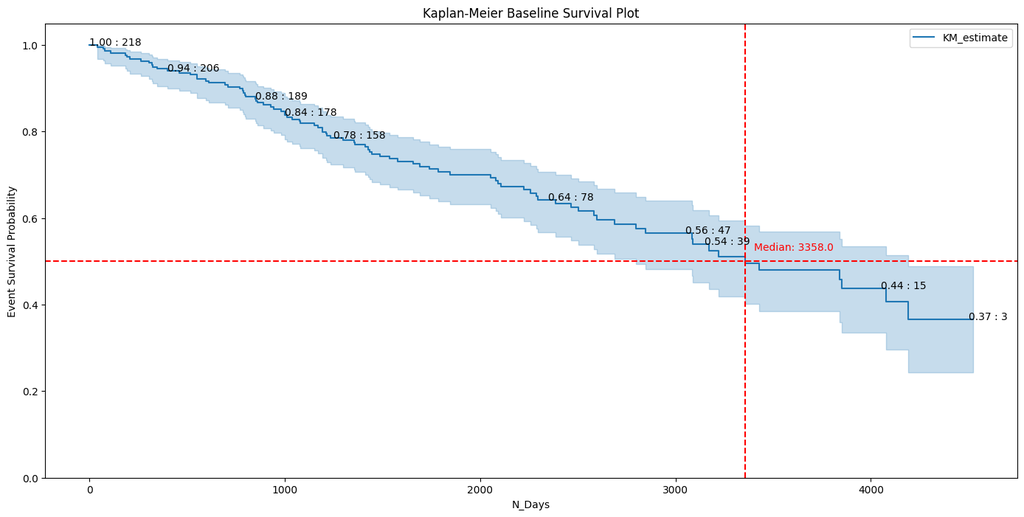

```python
##################################
# Plotting the baseline survival curve
# and computing the survival rates
##################################
kmf = KaplanMeierFitter()
kmf.fit(durations=cirrhosis_survival_train_EDA['N_Days'], event_observed=cirrhosis_survival_train_EDA['Status'])
plt.figure(figsize=(17, 8))
kmf.plot_survival_function()
plt.title('Kaplan-Meier Baseline Survival Plot')
plt.ylim(0, 1.05)
plt.xlabel('N_Days')
plt.ylabel('Event Survival Probability')

##################################
# Determing the at-risk numbers
##################################
at_risk_counts = kmf.event_table.at_risk
survival_probabilities = kmf.survival_function_.values.flatten()
time_points = kmf.survival_function_.index
for time, prob, at_risk in zip(time_points, survival_probabilities, at_risk_counts):
    if time % 50 == 0:
        plt.text(time, prob, f'{prob:.2f} : {at_risk}', ha='left', fontsize=10)
median_survival_time = kmf.median_survival_time_
plt.axvline(x=median_survival_time, color='r', linestyle='--')
plt.axhline(y=0.5, color='r', linestyle='--')
plt.text(3400, 0.52, f'Median: {median_survival_time}', ha='left', va='bottom', color='r', fontsize=10)
plt.show()
```

```python
##################################
# Computing the median survival time
##################################
median_survival_time = kmf.median_survival_time_
print(f'Median Survival Time: {median_survival_time}')
```

```
Median Survival Time: 3358.0
```

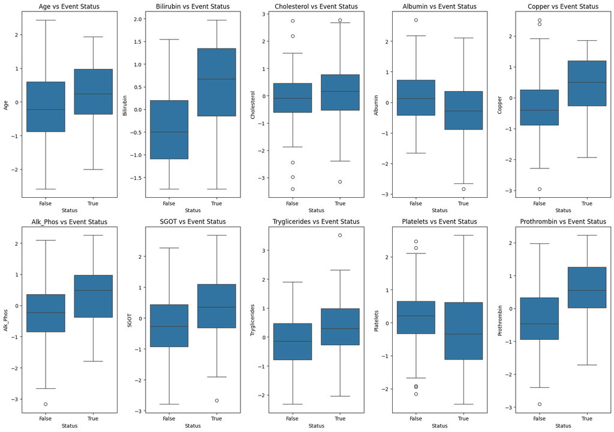

```python
##################################
# Exploring the relationships between
# the numeric predictors and event status
##################################
cirrhosis_survival_numeric_predictors = ['Age', 'Bilirubin','Cholesterol', 'Albumin','Copper', 'Alk_Phos','SGOT', 'Tryglicerides','Platelets', 'Prothrombin']
plt.figure(figsize=(17, 12))
for i in range(1, 11):
    plt.subplot(2, 5, i)
    sns.boxplot(x='Status', y=cirrhosis_survival_numeric_predictors[i-1], data=cirrhosis_survival_train_EDA)
    plt.title(f'{cirrhosis_survival_numeric_predictors[i-1]} vs Event Status')
plt.tight_layout()
plt.show()
```

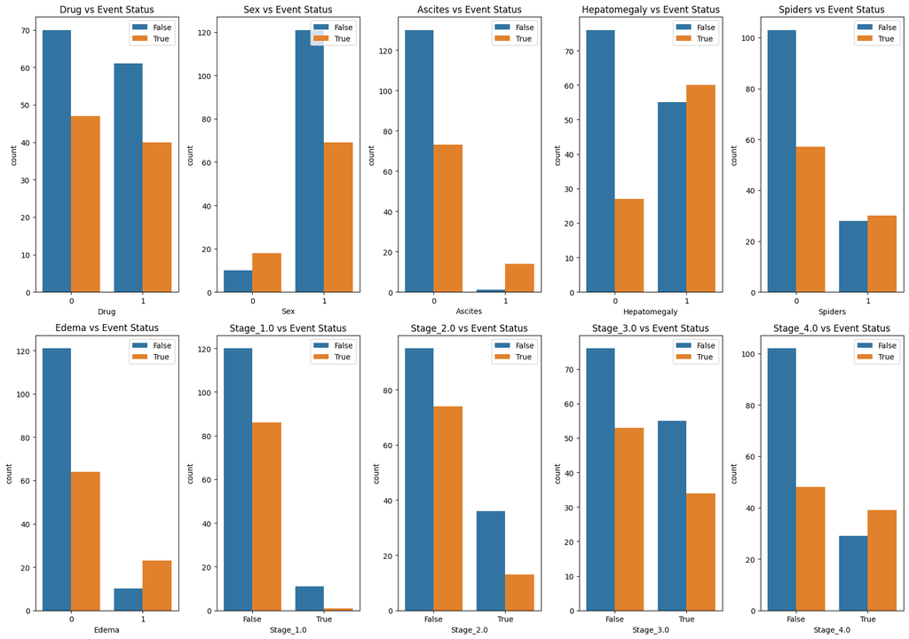

```python
##################################
# Exploring the relationships between
# the object predictors and event status
##################################
cirrhosis_survival_object_predictors = ['Drug', 'Sex','Ascites', 'Hepatomegaly','Spiders', 'Edema','Stage_1.0','Stage_2.0','Stage_3.0','Stage_4.0']
plt.figure(figsize=(17, 12))
for i in range(1, 11):
    plt.subplot(2, 5, i)
    sns.countplot(x=cirrhosis_survival_object_predictors[i-1], hue='Status', data=cirrhosis_survival_train_EDA)
    plt.title(f'{cirrhosis_survival_object_predictors[i-1]} vs Event Status')
    plt.legend(loc='upper right')
plt.tight_layout()
plt.show()
```

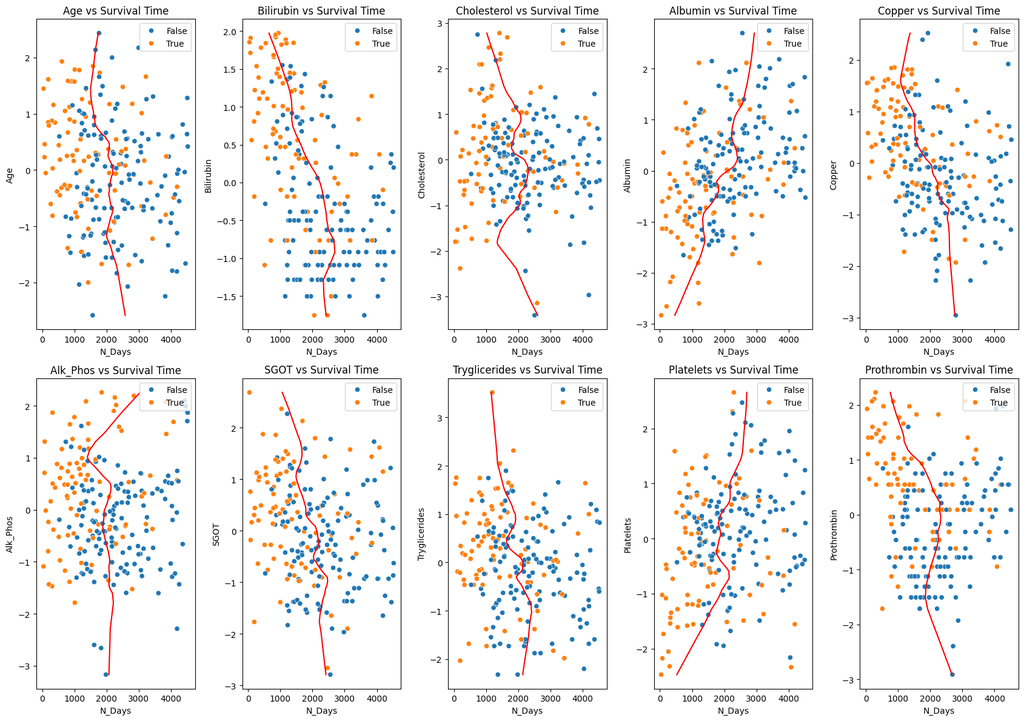

```python
##################################
# Exploring the relationships between
# the numeric predictors and survival time
##################################
plt.figure(figsize=(17, 12))
for i in range(1, 11):
    plt.subplot(2, 5, i)
    sns.scatterplot(x='N_Days', y=cirrhosis_survival_numeric_predictors[i-1], data=cirrhosis_survival_train_EDA, hue='Status')
    loess_smoothed = lowess(cirrhosis_survival_train_EDA['N_Days'], cirrhosis_survival_train_EDA[cirrhosis_survival_numeric_predictors[i-1]], frac=0.3)
    plt.plot(loess_smoothed[:, 1], loess_smoothed[:, 0], color='red')
    plt.title(f'{cirrhosis_survival_numeric_predictors[i-1]} vs Survival Time')
    plt.legend(loc='upper right')
plt.tight_layout()
plt.show()
```

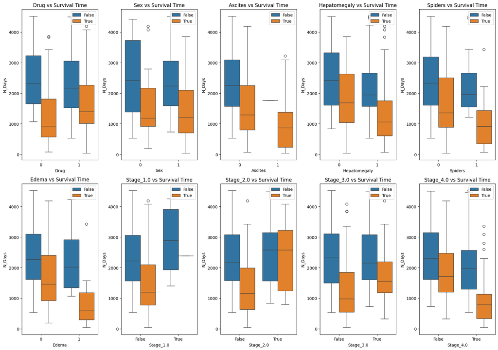

```python
##################################
# Exploring the relationships between
# the object predictors and survival time
##################################
plt.figure(figsize=(17, 12))
for i in range(1, 11):
    plt.subplot(2, 5, i)
    sns.boxplot(x=cirrhosis_survival_object_predictors[i-1], y='N_Days', hue='Status', data=cirrhosis_survival_train_EDA)
    plt.title(f'{cirrhosis_survival_object_predictors[i-1]} vs Survival Time')
    plt.legend(loc='upper right')
plt.tight_layout()
plt.show()
```

### 1.5.2 Hypothesis Testing

```python
##################################
# Computing the t-test
# statistic and p-values
# between the event variable
# and numeric predictor columns
##################################
cirrhosis_survival_numeric_ttest_event = {}
for numeric_column in cirrhosis_survival_numeric_predictors:
    group_0 = cirrhosis_survival_train_EDA[cirrhosis_survival_train_EDA.loc[:,'Status']==False]
    group_1 = cirrhosis_survival_train_EDA[cirrhosis_survival_train_EDA.loc[:,'Status']==True]
    cirrhosis_survival_numeric_ttest_event['Status_' + numeric_column] = stats.ttest_ind(
        group_0[numeric_column],
        group_1[numeric_column],
        equal_var=True)
```

```python
##################################
# Formulating the pairwise ttest summary
# between the event variable
# and numeric predictor columns
##################################
cirrhosis_survival_numeric_ttest_summary = cirrhosis_survival_train_EDA.from_dict(cirrhosis_survival_numeric_ttest_event, orient='index')
cirrhosis_survival_numeric_ttest_summary.columns = ['T.Test.Statistic', 'T.Test.PValue']
display(cirrhosis_survival_numeric_ttest_summary.sort_values(by=['T.Test.PValue'], ascending=True))
```

|  | T.Test.Statistic | T.Test.PValue |
| --- | --- | --- |
| Status_Bilirubin | -8.030789 | 6.198797e-14 |
| Status_Prothrombin | -7.062933 | 2.204961e-11 |
| Status_Copper | -5.699409 | 3.913575e-08 |
| Status_Alk_Phos | -4.638524 | 6.077981e-06 |
| Status_SGOT | -4.207123 | 3.791642e-05 |
| Status_Albumin | 3.871216 | 1.434736e-04 |
| Status_Tryglicerides | -3.575779 | 4.308371e-04 |
| Status_Age | -3.264563 | 1.274679e-03 |
| Status_Platelets | 3.261042 | 1.289850e-03 |
| Status_Cholesterol | -2.256073 | 2.506758e-02 |

```python
##################################
# Computing the chisquare
# statistic and p-values
# between the event variable
# and categorical predictor columns
##################################
cirrhosis_survival_object_chisquare_event = {}
for object_column in cirrhosis_survival_object_predictors:
    contingency_table = pd.crosstab(cirrhosis_survival_train_EDA[object_column],
                                    cirrhosis_survival_train_EDA['Status'])
    cirrhosis_survival_object_chisquare_event['Status_' + object_column] = stats.chi2_contingency(
        contingency_table)[0:2]
```

```python
##################################
# Formulating the pairwise chisquare summary
# between the event variable
# and categorical predictor columns
##################################
cirrhosis_survival_object_chisquare_event_summary = cirrhosis_survival_train_EDA.from_dict(cirrhosis_survival_object_chisquare_event, orient='index')
cirrhosis_survival_object_chisquare_event_summary.columns = ['ChiSquare.Test.Statistic', 'ChiSquare.Test.PValue']
display(cirrhosis_survival_object_chisquare_event_summary.sort_values(by=['ChiSquare.Test.PValue'], ascending=True))
```

|  | ChiSquare.Test.Statistic | ChiSquare.Test.PValue |
| --- | --- | --- |
| Status_Ascites | 16.854134 | 0.000040 |
| Status_Hepatomegaly | 14.206045 | 0.000164 |
| Status_Edema | 12.962303 | 0.000318 |
| Status_Stage_4.0 | 11.505826 | 0.000694 |
| Status_Sex | 6.837272 | 0.008928 |
| Status_Stage_2.0 | 4.024677 | 0.044839 |
| Status_Stage_1.0 | 3.977918 | 0.046101 |
| Status_Spiders | 3.953826 | 0.046765 |
| Status_Stage_3.0 | 0.082109 | 0.774459 |
| Status_Drug | 0.000000 | 1.000000 |

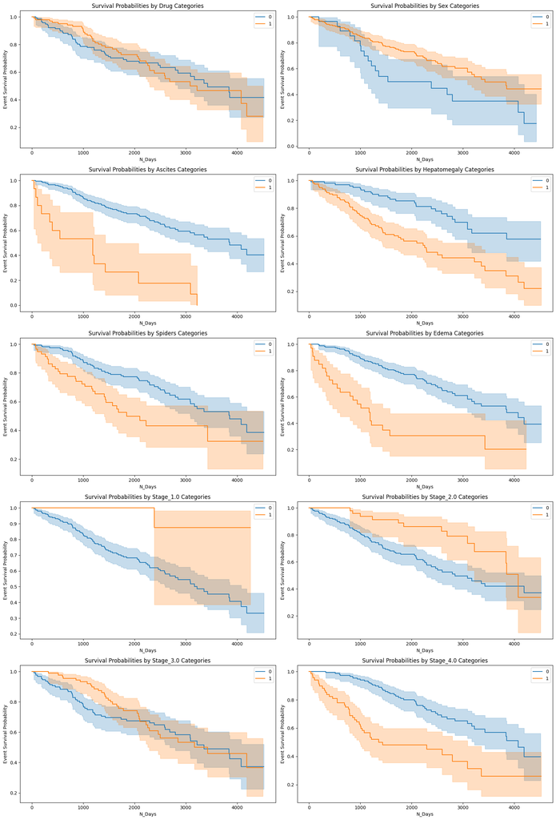

```python
##################################
# Exploring the relationships between
# the object predictors with
# survival event and duration
##################################
plt.figure(figsize=(17, 25))
for i in range(0, len(cirrhosis_survival_object_predictors)):
    ax = plt.subplot(5, 2, i+1)
    for group in [0,1]:
        kmf.fit(durations=cirrhosis_survival_train_EDA[cirrhosis_survival_train_EDA[cirrhosis_survival_object_predictors[i]] == group]['N_Days'],
                event_observed=cirrhosis_survival_train_EDA[cirrhosis_survival_train_EDA[cirrhosis_survival_object_predictors[i]] == group]['Status'], label=group)
        kmf.plot_survival_function(ax=ax)
    plt.title(f'Survival Probabilities by {cirrhosis_survival_object_predictors[i]} Categories')
    plt.xlabel('N_Days')
    plt.ylabel('Event Survival Probability')
plt.tight_layout()
plt.show()
```

```python
##################################
# Computing the log-rank test
# statistic and p-values
# between the event and duration variables
# with the object predictor columns
##################################
cirrhosis_survival_object_lrtest_event = {}
for object_column in cirrhosis_survival_object_predictors:
    groups = [0,1]
    group_0_event = cirrhosis_survival_train_EDA[cirrhosis_survival_train_EDA[object_column] == groups[0]]['Status']
    group_1_event = cirrhosis_survival_train_EDA[cirrhosis_survival_train_EDA[object_column] == groups[1]]['Status']
    group_0_duration = cirrhosis_survival_train_EDA[cirrhosis_survival_train_EDA[object_column] == groups[0]]['N_Days']
    group_1_duration = cirrhosis_survival_train_EDA[cirrhosis_survival_train_EDA[object_column] == groups[1]]['N_Days']
    lr_test = logrank_test(group_0_duration, group_1_duration,event_observed_A=group_0_event, event_observed_B=group_1_event)
    cirrhosis_survival_object_lrtest_event['Status_NDays_' + object_column] = (lr_test.test_statistic, lr_test.p_value)
```

```python
##################################
# Formulating the log-rank test summary
# between the event and duration variables
# with the object predictor columns
##################################
cirrhosis_survival_object_lrtest_summary = cirrhosis_survival_train_EDA.from_dict(cirrhosis_survival_object_lrtest_event, orient='index')
cirrhosis_survival_object_lrtest_summary.columns = ['LR.Test.Statistic', 'LR.Test.PValue']
display(cirrhosis_survival_object_lrtest_summary.sort_values(by=['LR.Test.PValue'], ascending=True))
```

|  | LR.Test.Statistic | LR.Test.PValue |
| --- | --- | --- |
| Status_NDays_Ascites | 37.792220 | 7.869499e-10 |
| Status_NDays_Edema | 31.619652 | 1.875223e-08 |
| Status_NDays_Stage_4.0 | 26.482676 | 2.659121e-07 |
| Status_NDays_Hepatomegaly | 20.360210 | 6.414988e-06 |
| Status_NDays_Spiders | 10.762275 | 1.035900e-03 |
| Status_NDays_Stage_2.0 | 6.775033 | 9.244176e-03 |
| Status_NDays_Sex | 5.514094 | 1.886385e-02 |
| Status_NDays_Stage_1.0 | 5.473270 | 1.930946e-02 |
| Status_NDays_Stage_3.0 | 0.478031 | 4.893156e-01 |
| Status_NDays_Drug | 0.000016 | 9.968084e-01 |

```python
##################################
# Creating an alternate copy of the
# EDA data which will utilize
# binning for numeric predictors
##################################
cirrhosis_survival_train_EDA_binned = cirrhosis_survival_train_EDA.copy()

##################################
# Creating a function to bin
# numeric predictors into two groups
##################################
def bin_numeric_predictor(df, predictor):
    median = df[predictor].median()
    df[f'Binned_{predictor}'] = np.where(df[predictor] <= median, 0, 1)
    return df

##################################
# Binning the numeric predictors
# in the alternate EDA data into two groups
##################################
for numeric_column in cirrhosis_survival_numeric_predictors:
    cirrhosis_survival_train_EDA_binned = bin_numeric_predictor(cirrhosis_survival_train_EDA_binned, numeric_column)

##################################
# Formulating the binned numeric predictors
##################################
cirrhosis_survival_binned_numeric_predictors = ["Binned_" + predictor for predictor in cirrhosis_survival_numeric_predictors]
```

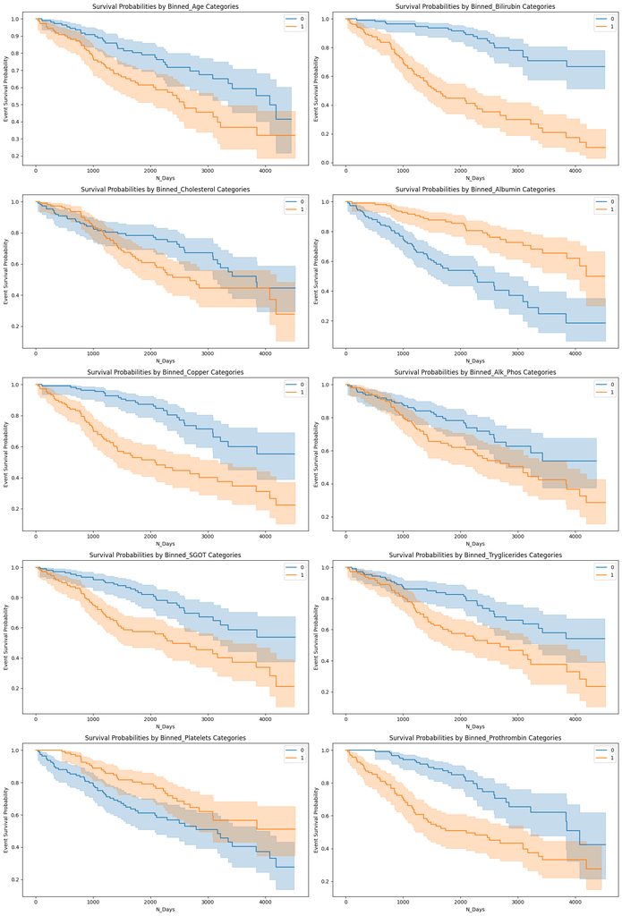

```python
##################################
# Exploring the relationships between
# the binned numeric predictors with
# survival event and duration
##################################
plt.figure(figsize=(17, 25))
for i in range(0, len(cirrhosis_survival_binned_numeric_predictors)):
    ax = plt.subplot(5, 2, i+1)
    for group in [0,1]:
        kmf.fit(durations=cirrhosis_survival_train_EDA_binned[cirrhosis_survival_train_EDA_binned[cirrhosis_survival_binned_numeric_predictors[i]] == group]['N_Days'],
                event_observed=cirrhosis_survival_train_EDA_binned[cirrhosis_survival_train_EDA_binned[cirrhosis_survival_binned_numeric_predictors[i]] == group]['Status'], label=group)
        kmf.plot_survival_function(ax=ax)
    plt.title(f'Survival Probabilities by {cirrhosis_survival_binned_numeric_predictors[i]} Categories')
    plt.xlabel('N_Days')
    plt.ylabel('Event Survival Probability')
plt.tight_layout()
plt.show()
```

```python
##################################
# Computing the log-rank test
# statistic and p-values
# between the event and duration variables
# with the binned numeric predictor columns
##################################
cirrhosis_survival_binned_numeric_lrtest_event = {}
for binned_numeric_column in cirrhosis_survival_binned_numeric_predictors:
    groups = [0,1]
    group_0_event = cirrhosis_survival_train_EDA_binned[cirrhosis_survival_train_EDA_binned[binned_numeric_column] == groups[0]]['Status']
    group_1_event = cirrhosis_survival_train_EDA_binned[cirrhosis_survival_train_EDA_binned[binned_numeric_column] == groups[1]]['Status']
    group_0_duration = cirrhosis_survival_train_EDA_binned[cirrhosis_survival_train_EDA_binned[binned_numeric_column] == groups[0]]['N_Days']
    group_1_duration = cirrhosis_survival_train_EDA_binned[cirrhosis_survival_train_EDA_binned[binned_numeric_column] == groups[1]]['N_Days']
    lr_test = logrank_test(group_0_duration, group_1_duration,event_observed_A=group_0_event, event_observed_B=group_1_event)
    cirrhosis_survival_binned_numeric_lrtest_event['Status_NDays_' + binned_numeric_column] = (lr_test.test_statistic, lr_test.p_value)
```

```python
##################################
# Formulating the log-rank test summary
# between the event and duration variables
# with the binned numeric predictor columns
##################################
cirrhosis_survival_binned_numeric_lrtest_summary = cirrhosis_survival_train_EDA_binned.from_dict(cirrhosis_survival_binned_numeric_lrtest_event, orient='index')
cirrhosis_survival_binned_numeric_lrtest_summary.columns = ['LR.Test.Statistic', 'LR.Test.PValue']
display(cirrhosis_survival_binned_numeric_lrtest_summary.sort_values(by=['LR.Test.PValue'], ascending=True))
```

|  | LR.Test.Statistic | LR.Test.PValue |
| --- | --- | --- |
| Status_NDays_Binned_Bilirubin | 62.559303 | 2.585412e-15 |
| Status_NDays_Binned_Albumin | 29.444808 | 5.753197e-08 |
| Status_NDays_Binned_Copper | 27.452421 | 1.610072e-07 |
| Status_NDays_Binned_Prothrombin | 21.695995 | 3.194575e-06 |
| Status_NDays_Binned_SGOT | 16.178483 | 5.764520e-05 |
| Status_NDays_Binned_Tryglicerides | 11.512960 | 6.911262e-04 |
| Status_NDays_Binned_Age | 9.011700 | 2.682568e-03 |
| Status_NDays_Binned_Platelets | 6.741196 | 9.421142e-03 |
| Status_NDays_Binned_Alk_Phos | 5.503850 | 1.897465e-02 |
| Status_NDays_Binned_Cholesterol | 3.773953 | 5.205647e-02 |

### 1.6.1 Premodelling Data Description

1. To improve interpretation, reduce dimensionality and avoid inducing design matrix singularity, 3 object predictors were dropped prior to modelling:
   - Stage_1.0
   - Stage_2.0
   - Stage_3.0
2. To evaluate the feature selection capabilities of the candidate models, all remaining predictors were accounted during the model development process using the training subset:
   - **218 rows** (observations)
   - **19 columns** (variables)
     - **2/19 event | duration** (boolean | numeric)
       - Status
       - N_Days
     - **10/19 predictor** (numeric)
       - Age
       - Bilirubin
       - Cholesterol
       - Albumin
       - Copper
       - Alk_Phos
       - SGOT
       - Triglycerides
       - Platelets
       - Prothrombin
     - **7/19 predictor** (object)
       - Drug
       - Sex
       - Ascites
       - Hepatomegaly
       - Spiders
       - Edema
       - Stage_4.0
3. Similarly, all remaining predictors were accounted during the model evaluation process using the testing subset:
   - **94 rows** (observations)
   - **19 columns** (variables)
     - **2/19 event | duration** (boolean | numeric)
       - Status
       - N_Days
     - **10/19 predictor** (numeric)
       - Age
       - Bilirubin
       - Cholesterol
       - Albumin
       - Copper
       - Alk_Phos
       - SGOT
       - Triglycerides
       - Platelets
       - Prothrombin
     - **7/19 predictor** (object)
       - Drug
       - Sex
       - Ascites
       - Hepatomegaly
       - Spiders
       - Edema
       - Stage_4.0

```python
##################################
# Formulating a complete dataframe
# from the training subset for modelling
##################################
cirrhosis_survival_y_train_cleaned.reset_index(drop=True, inplace=True)
cirrhosis_survival_train_modeling = pd.concat([cirrhosis_survival_y_train_cleaned,
                                               cirrhosis_survival_X_train_preprocessed],
                                              axis=1)
cirrhosis_survival_train_modeling.drop(columns=['Stage_1.0', 'Stage_2.0', 'Stage_3.0'], axis=1, inplace=True)
cirrhosis_survival_train_modeling['Stage_4.0'] = cirrhosis_survival_train_modeling['Stage_4.0'].replace({True: 1, False: 0})
cirrhosis_survival_train_modeling.head()
```

|  | Status | N_Days | Age | Bilirubin | Cholesterol | Albumin | Copper | Alk_Phos | SGOT | Tryglicerides | Platelets | Prothrombin | Drug | Sex | Ascites | Hepatomegaly | Spiders | Edema | Stage_4.0 |
| --- | --- | --- | --- | --- | --- | --- | --- | --- | --- | --- | --- | --- | --- | --- | --- | --- | --- | --- | --- |
| 0 | False | 2475 | -1.342097 | 0.863802 | 0.886087 | -0.451884 | -0.972098 | 0.140990 | 0.104609 | 0.155130 | 0.540960 | 0.747580 | 1 | 1 | 0 | 0 | 0 | 0 | 0 |
| 1 | False | 877 | -1.470901 | 0.516350 | 1.554523 | 0.827618 | 0.467579 | -0.705337 | 0.301441 | 1.275222 | 0.474140 | -0.315794 | 1 | 0 | 0 | 0 | 0 | 0 | 0 |
| 2 | False | 3050 | -0.239814 | -0.625875 | 0.293280 | 0.646582 | -0.241205 | -0.848544 | 0.275723 | -1.684460 | 0.756741 | 0.087130 | 1 | 1 | 0 | 0 | 0 | 0 | 0 |
| 3 | True | 110 | -0.052733 | 0.559437 | -1.534283 | 0.354473 | -0.284113 | -0.014525 | 0.162878 | -0.189139 | -1.735375 | 0.649171 | 0 | 1 | 1 | 1 | 1 | 1 | 1 |
| 4 | True | 3839 | -0.795010 | 1.142068 | -0.108933 | -0.272913 | 0.618030 | 2.071847 | 1.434674 | -0.212684 | -0.675951 | -0.315794 | 0 | 1 | 0 | 1 | 0 | 0 | 0 |

```python
##################################
# Formulating a complete dataframe
# from the testing subset for modelling
##################################
cirrhosis_survival_y_test_cleaned.reset_index(drop=True, inplace=True)
cirrhosis_survival_test_modeling = pd.concat([cirrhosis_survival_y_test_cleaned,
                                               cirrhosis_survival_X_test_preprocessed],
                                              axis=1)
cirrhosis_survival_test_modeling.drop(columns=['Stage_1.0', 'Stage_2.0', 'Stage_3.0'], axis=1, inplace=True)
cirrhosis_survival_test_modeling['Stage_4.0'] = cirrhosis_survival_test_modeling['Stage_4.0'].replace({True: 1, False: 0})
cirrhosis_survival_test_modeling.head()
```

|  | Status | N_Days | Age | Bilirubin | Cholesterol | Albumin | Copper | Alk_Phos | SGOT | Tryglicerides | Platelets | Prothrombin | Drug | Sex | Ascites | Hepatomegaly | Spiders | Edema | Stage_4.0 |
| --- | --- | --- | --- | --- | --- | --- | --- | --- | --- | --- | --- | --- | --- | --- | --- | --- | --- | --- | --- |
| 0 | False | 3336 | 1.043704 | 0.744396 | 0.922380 | 0.240951 | 0.045748 | 0.317282 | -0.078335 | 2.671950 | 1.654815 | -0.948196 | 1 | 1 | 0 | 0 | 1 | 1 | 0 |
| 1 | False | 1321 | -1.936476 | -0.764558 | 0.160096 | -0.600950 | -0.179138 | -0.245613 | 0.472422 | -0.359800 | 0.348533 | 0.439089 | 0 | 1 | 0 | 0 | 0 | 0 | 1 |
| 2 | False | 1435 | -1.749033 | 0.371523 | 0.558115 | 0.646582 | -0.159024 | 0.339454 | 0.685117 | -3.109146 | -0.790172 | -0.617113 | 1 | 1 | 0 | 1 | 0 | 0 | 1 |
| 3 | False | 4459 | -0.485150 | -0.918484 | -0.690904 | 1.629765 | 0.028262 | 1.713791 | -1.387751 | 0.155130 | 0.679704 | 0.087130 | 1 | 0 | 0 | 0 | 0 | 0 | 0 |
| 4 | False | 2721 | -0.815655 | 1.286438 | 2.610501 | -0.722153 | 0.210203 | 0.602860 | 3.494936 | -0.053214 | -0.475634 | -1.714435 | 0 | 1 | 0 | 1 | 0 | 0 | 0 |

### 1.6.2 Weibull Accelerated Failure Time Model

[Survival Analysis](https://link.springer.com/book/10.1007/978-1-4419-6646-9/) deals with the analysis of time-to-event data. It focuses on the expected duration of time until one or more events of interest occur, such as death, failure, or relapse. This type of analysis is used to study and model the time until the occurrence of an event, taking into account that the event might not have occurred for all subjects during the study period. Several key aspects of survival analysis include the survival function which refers to the probability that an individual survives longer than a certain time, hazard function which describes the instantaneous rate at which events occur, given no prior event, and censoring pertaining to a condition where the event of interest has not occurred for some subjects during the observation period.

[Right-Censored Survival Data](https://link.springer.com/book/10.1007/978-1-4419-6646-9/) occurs when the event of interest has not happened for some subjects by the end of the study period or the last follow-up time. This type of censoring is common in survival analysis because not all individuals may experience the event before the study ends, or they might drop out or be lost to follow-up. Right-censored data is crucial in survival analysis as it allows the inclusion of all subjects in the analysis, providing more accurate and reliable estimates.

[Accelerated Failure Time Models](https://link.springer.com/book/10.1007/978-1-4419-6646-9/) are a class of survival analysis models used to analyze time-to-event data by directly modelling the survival time itself. An AFT model assumes that the effect of covariates accelerates or decelerates the life time of an event by some constant factor. The mathematical equation is represented by the logarithm of the survival time being equal to the sum of the vector of covariates multiplied to the vector of regression coefficients; and the product of the scale parameter and a random variable with a specified distribution. In an AFT model, the coefficients represent the multiplicative effect on the survival time. An exponentiated regression coefficient greater than one prolongs survival time, while a value less than one shortens it. The scale parameter determines the spread or variability of survival times. AFT models assume that the effect of covariates on survival time is multiplicative and that the survival times can be transformed to follow a specific distribution.

[Weibull Accelerated Failure Time Models](https://link.springer.com/book/10.1007/978-1-4419-6646-9/) assumes that the survival time errors follow a Weibull distribution. The mathematical equation is represented by the logarithm of the survival time being equal to the sum of the vector of covariates multiplied to the vector of regression coefficients; and the product of the scale parameter and a Weibull-distributed error term. This model is flexible as it can model both increasing and decreasing hazard rates over time and can be used to model various types of survival data. However, the results may be complex to interpret if the shape parameter does not align well with the data, and the model can also be sensitive to the distributional assumptions.

[Concordance Index](https://lifelines.readthedocs.io/en/latest/lifelines.utils.html) measures the model's ability to correctly order pairs of observations based on their predicted survival times. Values range from 0.5 to 1.0 indicating no predictive power (random guessing) and perfect predictions, respectively. As a metric, it provides a measure of discriminative ability and useful for ranking predictions. However, it does not provide information on the magnitude of errors and may be insensitive to the calibration of predicted survival probabilities.

[Mean Absolute Error](https://scikit-learn.org/stable/modules/generated/sklearn.metrics.mean_absolute_error.html) measures the average magnitude of the errors between predicted and actual survival times. Lower MAE values indicate better model performance, while reflecting the average prediction error in the same units as the survival time. As a metric, it is intuitive and easy to interpret while providing a direct measure of prediction accuracy. However, it may be sensitive to outliers and does not consider the probabilistic nature of survival predictions.

[Brier Score](https://scikit-learn.org/stable/modules/generated/sklearn.metrics.brier_score_loss.html) measures the accuracy of probabilistic predictions of survival at a specific time point. Values range from 0 to 1 with a lower brier scores indicating better accuracy. A Brier score of 0 indicates perfect predictions, while a score of 1 indicates the worst possible predictions. As a metric, it considers both discrimination and calibration, while reflecting the accuracy of predicted survival probabilities. However, it requires specifying a time point and aggregating scores over time points may be less interpretable.

1. The [weibull accelerated failure time model](https://lifelines.readthedocs.io/en/latest/fitters/regression/WeibullAFTFitter.html) from the **lifelines.WeibullAFTFitter** Python library API was implemented.
2. The model implementation used 1 hyperparameter:
   - penalizer = penalty to the size of the coefficients during regression fixed at a value = 0.30
3. Only 3 of the 17 predictors, which were determined by the model as statistically significant, were used for prediction:
   - Bilirubin: Increase in value associated with a decrease in time to event
   - Prothrombin: Increase in value associated with a decrease in time to event
   - Age: Increase in value associated with a decrease in time to event
4. The cross-validated model performance of the model is summarized as follows:
   - **Concordance Index** = 0.8250
   - **Mean Absolute Error** = 2303.6056
   - **Brier Score** = 0.5125
5. The apparent model performance of the model is summarized as follows:
   - **Concordance Index** = 0.8291
   - **Mean Absolute Error** = 2280.7437
   - **Brier Score** = 0.5151
6. The independent test model performance of the model is summarized as follows:
   - **Concordance Index** = 0.8526
   - **Mean Absolute Error** = 1948.8733
   - **Brier Score** = 0.5375
7. Comparable apparent and cross-validated model performance was observed, indicative of the presence of minimal model overfitting.
8. The MAE for event observations were typically lower because the errors were directly tied to the observed event times, which are known and can be more accurately predicted. For censored observations, the prediction error reflects the model's inability to pinpoint the exact event time, leading to higher MAE due to the larger variability and the longer tail of potential event times beyond the censoring point.
9. Survival probability curves estimated for all cases. Shorter median survival times were observed for:
   - Event cases as compared to censored cases
   - Higher values for Bilirubin as compared to lower values
   - Higher values for Prothrombin as compared to lower values
   - Higher values for Age as compared to lower values
10. SHAP values were computed for the significant predictors, with contributions to the model output ranked as follows:
    - Higher values for Bilirubin result to the event expected to occur sooner
    - Higher values for Prothrombin result to the event expected to occur sooner
    - Higher values for Age result to the event expected to occur sooner

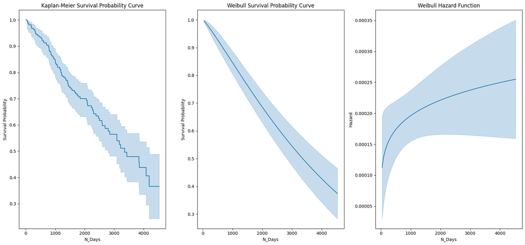

```python
##################################
# Assessing the survival probability
# and hazard function plots
# with a Weibull distribution
##################################
cirrhosis_survival_weibull = WeibullFitter()
cirrhosis_survival_weibull.fit(durations=cirrhosis_survival_train_modeling['N_Days'],
                               event_observed=cirrhosis_survival_train_modeling['Status'])

##################################
# Fitting a Kaplan-Meier estimation
##################################
cirrhosis_survival_km = KaplanMeierFitter()
cirrhosis_survival_km.fit(durations=cirrhosis_survival_train_modeling['N_Days'],
                          event_observed=cirrhosis_survival_train_modeling['Status'])

##################################
# Generating the survival probability
# and hazard function plots
##################################
plt.figure(figsize=(17, 8))

##################################
# Generating the Kaplan-Meier
# survival probability plot
##################################
plt.subplot(1, 3, 1)
cirrhosis_survival_km.plot_survival_function()
plt.title("Kaplan-Meier Survival Probability Curve")
plt.xlabel("N_Days")
plt.ylabel("Survival Probability")
plt.legend('',frameon=False)

##################################
# Generating the Weibull
# survival probability plot
##################################
plt.subplot(1, 3, 2)
cirrhosis_survival_weibull.plot_survival_function()
plt.title("Weibull Survival Probability Curve")
plt.xlabel("N_Days")
plt.ylabel("Survival Probability")
plt.legend('',frameon=False)

##################################
# Generating the Weibull
# hazard function plot
##################################
plt.subplot(1, 3, 3)
cirrhosis_survival_weibull.plot_hazard()
plt.title("Weibull Hazard Function")
plt.xlabel("N_Days")
plt.ylabel("Hazard")
plt.legend('',frameon=False)

##################################
# Consolidating all plots
##################################
plt.tight_layout()
plt.show()
```

```python
##################################
# Formulating the Accelerated Failure Time model
# based on a Weibull distribution
# and generating the summary
##################################
cirrhosis_survival_aft_weibull = WeibullAFTFitter(penalizer=0.30)
cirrhosis_survival_aft_weibull.fit(cirrhosis_survival_train_modeling, duration_col='N_Days', event_col='Status')
cirrhosis_survival_aft_weibull.print_summary()
```

| model | lifelines.WeibullAFTFitter |
| --- | --- |
| duration col | 'N_Days' |
| event col | 'Status' |
| penalizer | 0.3 |
| number of observations | 218 |
| number of events observed | 87 |
| log-likelihood | -777.86 |
| time fit was run | 2024-10-14 07:41:30 UTC |

|  |  | coef | exp(coef) | se(coef) | coef lower 95% | coef upper 95% | exp(coef) lower 95% | exp(coef) upper 95% | cmp to | z | p | -log2(p) |
| --- | --- | --- | --- | --- | --- | --- | --- | --- | --- | --- | --- | --- |
| lambda_ | Age | -0.17 | 0.85 | 0.07 | -0.30 | -0.03 | 0.74 | 0.98 | 0.00 | -2.31 | 0.02 | 5.59 |
|  | Albumin | 0.10 | 1.10 | 0.08 | -0.05 | 0.25 | 0.95 | 1.28 | 0.00 | 1.27 | 0.20 | 2.29 |
|  | Alk_Phos | -0.04 | 0.96 | 0.07 | -0.18 | 0.11 | 0.83 | 1.11 | 0.00 | -0.52 | 0.60 | 0.74 |
|  | Ascites | -0.20 | 0.82 | 0.23 | -0.66 | 0.26 | 0.51 | 1.29 | 0.00 | -0.87 | 0.38 | 1.38 |
|  | Bilirubin | -0.29 | 0.75 | 0.09 | -0.46 | -0.12 | 0.63 | 0.88 | 0.00 | -3.39 | <0.005 | 10.47 |
|  | Cholesterol | -0.05 | 0.95 | 0.08 | -0.20 | 0.10 | 0.82 | 1.11 | 0.00 | -0.61 | 0.54 | 0.89 |
|  | Copper | -0.11 | 0.89 | 0.08 | -0.27 | 0.04 | 0.77 | 1.04 | 0.00 | -1.46 | 0.15 | 2.79 |
|  | Drug | 0.10 | 1.10 | 0.14 | -0.17 | 0.37 | 0.84 | 1.44 | 0.00 | 0.71 | 0.48 | 1.07 |
|  | Edema | -0.33 | 0.72 | 0.18 | -0.68 | 0.01 | 0.51 | 1.01 | 0.00 | -1.88 | 0.06 | 4.05 |
|  | Hepatomegaly | -0.11 | 0.90 | 0.15 | -0.40 | 0.19 | 0.67 | 1.20 | 0.00 | -0.72 | 0.47 | 1.08 |
|  | Platelets | 0.05 | 1.06 | 0.07 | -0.08 | 0.19 | 0.92 | 1.21 | 0.00 | 0.77 | 0.44 | 1.18 |
|  | Prothrombin | -0.19 | 0.83 | 0.08 | -0.34 | -0.05 | 0.71 | 0.96 | 0.00 | -2.56 | 0.01 | 6.57 |
|  | SGOT | -0.11 | 0.90 | 0.08 | -0.26 | 0.04 | 0.77 | 1.04 | 0.00 | -1.44 | 0.15 | 2.74 |
|  | Sex | 0.02 | 1.02 | 0.19 | -0.35 | 0.40 | 0.70 | 1.49 | 0.00 | 0.11 | 0.91 | 0.14 |
|  | Spiders | -0.04 | 0.96 | 0.16 | -0.35 | 0.27 | 0.71 | 1.30 | 0.00 | -0.26 | 0.79 | 0.33 |
|  | Stage_4.0 | -0.15 | 0.86 | 0.16 | -0.46 | 0.16 | 0.63 | 1.17 | 0.00 | -0.96 | 0.34 | 1.56 |
|  | Tryglicerides | -0.06 | 0.94 | 0.07 | -0.20 | 0.08 | 0.82 | 1.08 | 0.00 | -0.88 | 0.38 | 1.40 |
|  | Intercept | 8.52 | 5006.58 | 0.21 | 8.10 | 8.94 | 3292.49 | 7613.01 | 0.00 | 39.84 | <0.005 | inf |
| rho_ | Intercept | 0.34 | 1.41 | 0.07 | 0.20 | 0.49 | 1.22 | 1.63 | 0.00 | 4.61 | <0.005 | 17.96 |

| Concordance | 0.85 |
| --- | --- |
| AIC | 1593.72 |
| log-likelihood ratio test | 101.74 on 17 df |
| -log2(p) of ll-ratio test | 44.43 |

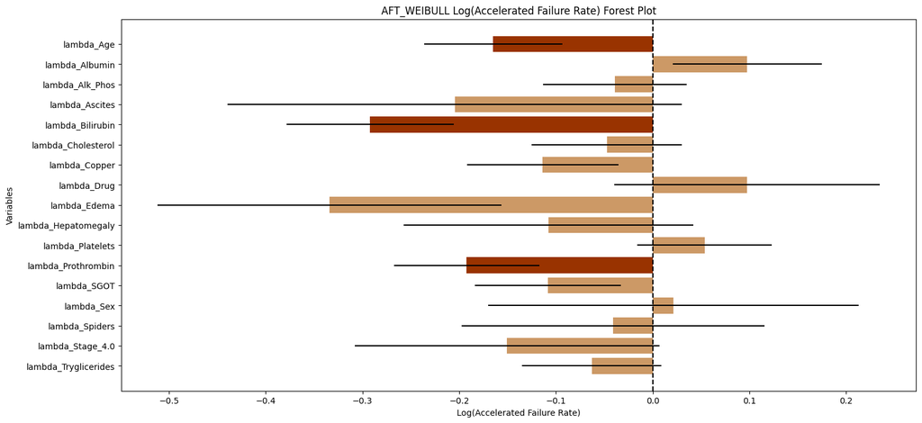

```python
##################################
# Plotting the log accelerated failure rate of the
# formulated Accelerated Failure Time model
# based on a Weibull distribution
##################################
cirrhosis_survival_aft_weibull_summary = cirrhosis_survival_aft_weibull.summary
cirrhosis_survival_aft_weibull_summary_params = pd.DataFrame(cirrhosis_survival_aft_weibull.params_)
significant = cirrhosis_survival_aft_weibull_summary['p'] < 0.05
cirrhosis_survival_aft_weibull_summary_log_accelerated_failure_rate = (list(cirrhosis_survival_aft_weibull_summary_params.iloc[:,0].values))
plt.figure(figsize=(17, 8))
colors = ['#993300' if sig else '#CC9966' for sig in significant]

plt.barh([(index[0] + index[1]) for index in cirrhosis_survival_aft_weibull_summary_params.index[0:17]],
         cirrhosis_survival_aft_weibull_summary_log_accelerated_failure_rate[0:17],
         xerr=cirrhosis_survival_aft_weibull_summary['se(coef)'][0:17],
         color=colors)
plt.xlabel('Log(Accelerated Failure Rate)')
plt.ylabel('Variables')
plt.title('AFT_WEIBULL Log(Accelerated Failure Rate) Forest Plot')
plt.axvline(x=0, color='k', linestyle='--')
plt.gca().invert_yaxis()
plt.show()
```

```python
##################################
# Determining the number of
# significant predictors
##################################
cirrhosis_survival_aft_weibull_significant = sum(cirrhosis_survival_aft_weibull_summary['p'] < 0.05)
display(f"Number of Significant Predictors: {cirrhosis_survival_aft_weibull_significant-2}")
```

```
'Number of Significant Predictors: 3'
```

```python
##################################
# Formulating the Accelerated Failure Time model
# based on a Weibull distribution,
# using the significant predictors only
# and generating the summary
##################################
feature_subset = ['Bilirubin','Prothrombin','Age','N_Days','Status']
cirrhosis_survival_aft_weibull = WeibullAFTFitter(penalizer=0.30)
cirrhosis_survival_aft_weibull.fit(cirrhosis_survival_train_modeling[feature_subset], duration_col='N_Days', event_col='Status')
cirrhosis_survival_aft_weibull.print_summary()
```

| model | lifelines.WeibullAFTFitter |
| --- | --- |
| duration col | 'N_Days' |
| event col | 'Status' |
| penalizer | 0.3 |
| number of observations | 218 |
| number of events observed | 87 |
| log-likelihood | -789.68 |
| time fit was run | 2024-10-14 07:41:31 UTC |

|  |  | coef | exp(coef) | se(coef) | coef lower 95% | coef upper 95% | exp(coef) lower 95% | exp(coef) upper 95% | cmp to | z | p | -log2(p) |
| --- | --- | --- | --- | --- | --- | --- | --- | --- | --- | --- | --- | --- |
| lambda_ | Age | -0.19 | 0.83 | 0.06 | -0.31 | -0.06 | 0.73 | 0.94 | 0.00 | -2.97 | <0.005 | 8.40 |
|  | Bilirubin | -0.51 | 0.60 | 0.07 | -0.64 | -0.38 | 0.53 | 0.68 | 0.00 | -7.56 | <0.005 | 44.52 |
|  | Prothrombin | -0.27 | 0.77 | 0.07 | -0.40 | -0.13 | 0.67 | 0.88 | 0.00 | -3.85 | <0.005 | 13.03 |
|  | Intercept | 8.36 | 4272.85 | 0.09 | 8.19 | 8.53 | 3594.18 | 5079.66 | 0.00 | 94.73 | <0.005 | inf |
| rho_ | Intercept | 0.35 | 1.42 | 0.07 | 0.21 | 0.50 | 1.23 | 1.64 | 0.00 | 4.74 | <0.005 | 18.81 |

| Concordance | 0.83 |
| --- | --- |
| AIC | 1589.35 |
| log-likelihood ratio test | 78.11 on 3 df |
| -log2(p) of ll-ratio test | 53.51 |

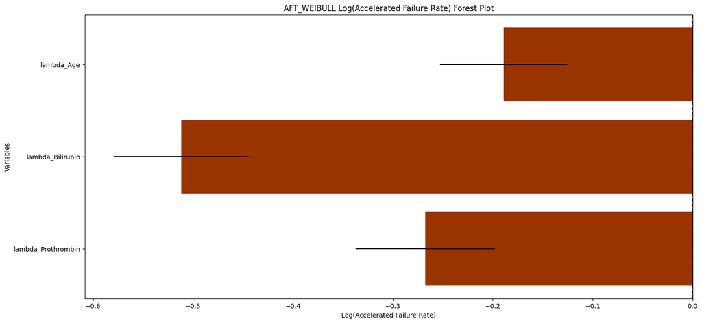

```python
##################################
# Plotting the log accelerated failure rate of the
# formulated Accelerated Failure Time model
# using the significant predictors only
# based on a Weibull distribution
##################################
cirrhosis_survival_aft_weibull_summary = cirrhosis_survival_aft_weibull.summary
cirrhosis_survival_aft_weibull_summary_params = pd.DataFrame(cirrhosis_survival_aft_weibull.params_)
significant = cirrhosis_survival_aft_weibull_summary['p'] < 0.05
cirrhosis_survival_aft_weibull_summary_log_accelerated_failure_rate = (list(cirrhosis_survival_aft_weibull_summary_params.iloc[:,0].values))
plt.figure(figsize=(17, 8))
colors = ['#993300' if sig else '#CC9966' for sig in significant]

plt.barh([(index[0] + index[1]) for index in cirrhosis_survival_aft_weibull_summary_params.index[0:3]],
         cirrhosis_survival_aft_weibull_summary_log_accelerated_failure_rate[0:3],
         xerr=cirrhosis_survival_aft_weibull_summary['se(coef)'][0:3],
         color=colors)
plt.xlabel('Log(Accelerated Failure Rate)')
plt.ylabel('Variables')
plt.title('AFT_WEIBULL Log(Accelerated Failure Rate) Forest Plot')
plt.axvline(x=0, color='k', linestyle='--')
plt.gca().invert_yaxis()
plt.show()
```

```python
##################################
# Gathering the apparent model performance
# as baseline for evaluating overfitting
##################################
cirrhosis_survival_aft_weibull.fit(cirrhosis_survival_train_modeling[feature_subset], duration_col='N_Days', event_col='Status')
train_predictions = cirrhosis_survival_aft_weibull.predict_median(cirrhosis_survival_train_modeling)
cirrhosis_survival_aft_weibull_train_ci = concordance_index(cirrhosis_survival_train_modeling['N_Days'],
                                                            train_predictions,
                                                            cirrhosis_survival_train_modeling['Status'])
time_point = cirrhosis_survival_train_modeling['N_Days'].median()
cirrhosis_survival_aft_weibull_train_mae = mean_absolute_error(cirrhosis_survival_train_modeling['N_Days'], train_predictions)
cirrhosis_survival_aft_weibull_train_brier = brier_score_loss(cirrhosis_survival_train_modeling['Status'],
                                                              cirrhosis_survival_aft_weibull.predict_survival_function(cirrhosis_survival_train_modeling,
                                                                                                                       times=[time_point]).T[time_point])
display(f"Apparent Concordance Index: {cirrhosis_survival_aft_weibull_train_ci}")
display(f"Apparent MAE: {cirrhosis_survival_aft_weibull_train_mae}")
display(f"Apparent Brier Score: {cirrhosis_survival_aft_weibull_train_brier}")
```

```
'Apparent Concordance Index: 0.8290799739921977'
```

```
'Apparent MAE: 2280.743783352582'
```

```
'Apparent Brier Score: 0.5151484140783107'
```

```python
##################################
# Performing 5-Fold Cross-Validation
# on the training data
##################################
kf = KFold(n_splits=5, shuffle=True, random_state=88888888)
ci_scores = []
mae_scores = []
brier_scores = []

for train_index, val_index in kf.split(cirrhosis_survival_train_modeling):
    df_train_fold = cirrhosis_survival_train_modeling.iloc[train_index]
    df_val_fold = cirrhosis_survival_train_modeling.iloc[val_index]

    cirrhosis_survival_aft_weibull.fit(df_train_fold[feature_subset], duration_col='N_Days', event_col='Status')
    val_predictions = cirrhosis_survival_aft_weibull.predict_median(df_val_fold)
    time_point = df_val_fold['N_Days'].median()
    ci = concordance_index(df_val_fold['N_Days'], val_predictions, df_val_fold['Status'])
    mae = mean_absolute_error(df_val_fold['N_Days'], val_predictions)
    brier = brier_score_loss(df_val_fold['Status'],
                             cirrhosis_survival_aft_weibull.predict_survival_function(df_val_fold,
                                                                                      times=[time_point]).T[time_point])
    ci_scores.append(ci)
    mae_scores.append(mae)
    brier_scores.append(brier)

cirrhosis_survival_aft_weibull_cv_ci_mean = np.mean(ci_scores)
cirrhosis_survival_aft_weibull_cv_ci_std = np.std(ci_scores)
cirrhosis_survival_aft_weibull_cv_mae_mean = np.mean(mae_scores)
cirrhosis_survival_aft_weibull_cv_brier_mean = np.mean(brier_scores)

display(f"Cross-Validated Concordance Index: {cirrhosis_survival_aft_weibull_cv_ci_mean}")
display(f"Cross-Validated MAE: {cirrhosis_survival_aft_weibull_cv_mae_mean}")
display(f"Cross-Validated Brier Score: {cirrhosis_survival_aft_weibull_cv_brier_mean}")
```

```
'Cross-Validated Concordance Index: 0.82500812019991'
```

```
'Cross-Validated MAE: 2303.605627546008'
```

```
'Cross-Validated Brier Score: 0.5125825238516044'
```

```python
##################################
# Evaluating the model performance
# on test data
##################################
test_predictions = cirrhosis_survival_aft_weibull.predict_median(cirrhosis_survival_test_modeling)
cirrhosis_survival_aft_weibull_test_ci = concordance_index(cirrhosis_survival_test_modeling['N_Days'],
                                                           test_predictions,
                                                           cirrhosis_survival_test_modeling['Status'])
time_point = cirrhosis_survival_test_modeling['N_Days'].median()
cirrhosis_survival_aft_weibull_test_mae = mean_absolute_error(cirrhosis_survival_test_modeling['N_Days'], test_predictions)
cirrhosis_survival_aft_weibull_test_brier = brier_score_loss(cirrhosis_survival_test_modeling['Status'],
                                                              cirrhosis_survival_aft_weibull.predict_survival_function(cirrhosis_survival_test_modeling,
                                                                                                                       times=[time_point]).T[time_point])
display(f"Apparent Concordance Index: {cirrhosis_survival_aft_weibull_test_ci}")
display(f"Apparent MAE: {cirrhosis_survival_aft_weibull_test_mae}")
display(f"Apparent Brier Score: {cirrhosis_survival_aft_weibull_test_brier}")
```

```
'Apparent Concordance Index: 0.8526077097505669'
```

```
'Apparent MAE: 1948.8733802238894'
```

```
'Apparent Brier Score: 0.5375559341601058'
```

```python
##################################
# Gathering the model performance metrics
# from training, cross-validation and test
##################################
aft_weibull_set = pd.DataFrame(["Train","Cross-Validation","Test"]*3)
aft_weibull_metric = pd.DataFrame((["Concordance.Index"]*3) + (["MAE"]*3) + (["Brier.Score"]*3))
aft_weibull_metric_values = pd.DataFrame([cirrhosis_survival_aft_weibull_train_ci,
                                           cirrhosis_survival_aft_weibull_cv_ci_mean,
                                           cirrhosis_survival_aft_weibull_test_ci,
                                           cirrhosis_survival_aft_weibull_train_mae,
                                           cirrhosis_survival_aft_weibull_cv_mae_mean,
                                           cirrhosis_survival_aft_weibull_test_mae,
                                           cirrhosis_survival_aft_weibull_train_brier,
                                           cirrhosis_survival_aft_weibull_cv_brier_mean,
                                           cirrhosis_survival_aft_weibull_test_brier])
aft_weibull_method = pd.DataFrame(["AFT_WEIBULL"]*9)
aft_weibull_summary = pd.concat([aft_weibull_set,
                                       aft_weibull_metric,
                                       aft_weibull_metric_values,
                                       aft_weibull_method],
                                      axis=1)
aft_weibull_summary.columns = ['Set', 'Metric', 'Value', 'Method']
aft_weibull_summary.reset_index(inplace=True, drop=True)
display(aft_weibull_summary)
```

|  | Set | Metric | Value | Method |
| --- | --- | --- | --- | --- |
| 0 | Train | Concordance.Index | 0.829080 | AFT_WEIBULL |
| 1 | Cross-Validation | Concordance.Index | 0.825008 | AFT_WEIBULL |
| 2 | Test | Concordance.Index | 0.852608 | AFT_WEIBULL |
| 3 | Train | MAE | 2280.743783 | AFT_WEIBULL |
| 4 | Cross-Validation | MAE | 2303.605628 | AFT_WEIBULL |
| 5 | Test | MAE | 1948.873380 | AFT_WEIBULL |
| 6 | Train | Brier.Score | 0.515148 | AFT_WEIBULL |
| 7 | Cross-Validation | Brier.Score | 0.512583 | AFT_WEIBULL |
| 8 | Test | Brier.Score | 0.537556 | AFT_WEIBULL |

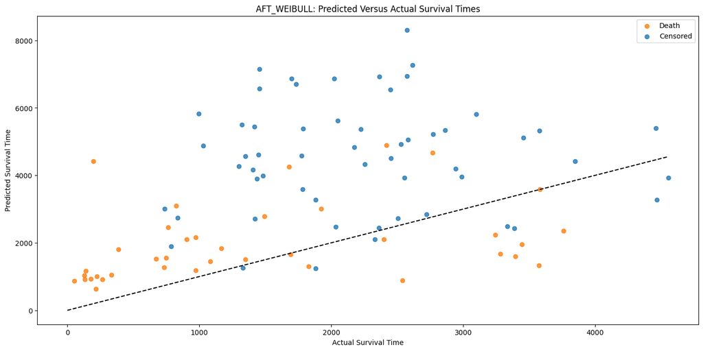

```python
##################################
# Evaluating the predicted
# and actual survival times
##################################
predicted_survival_times = cirrhosis_survival_aft_weibull.predict_median(cirrhosis_survival_test_modeling)
fig, ax = plt.subplots(figsize=(17, 8))
for status, color, label in zip([True, False], ['#FF7F0E','#1F77B4'], ['Death', 'Censored']):
    subset = cirrhosis_survival_test_modeling[cirrhosis_survival_test_modeling['Status'] == status]
    ax.scatter(subset['N_Days'], predicted_survival_times.iloc[subset.index], c=color, label=label, alpha=0.8)
ax.set_xlabel('Actual Survival Time')
ax.set_ylabel('Predicted Survival Time')
ax.set_title('AFT_WEIBULL: Predicted Versus Actual Survival Times')
ax.legend()
plt.plot([0, cirrhosis_survival_test_modeling['N_Days'].max()],
         [0, cirrhosis_survival_test_modeling['N_Days'].max()],
         color='black', linestyle='--')
plt.show()
```

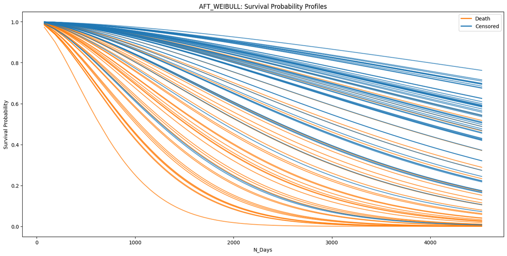

```python
##################################
# Plotting the individual
# survival probability profiles
##################################
plt.figure(figsize=(17, 8))
for status, color, label in zip([True, False], ['#FF7F0E','#1F77B4'], ['Death', 'Censored']):
    subset = cirrhosis_survival_test_modeling[cirrhosis_survival_test_modeling['Status'] == status]
    for i, row in subset.iterrows():
        survival_function = cirrhosis_survival_aft_weibull.predict_survival_function(row)
        plt.plot(survival_function.index, survival_function.iloc[:, 0], c=color, alpha=0.8)
plt.title('AFT_WEIBULL: Survival Probability Profiles')
plt.xlabel('N_Days')
plt.ylabel('Survival Probability')
death_patch = plt.Line2D([0], [0], color='#FF7F0E', lw=2, label='Death')
censored_patch = plt.Line2D([0], [0], color='#1F77B4', lw=2, label='Censored')
plt.legend(handles=[death_patch, censored_patch])
plt.show()
```

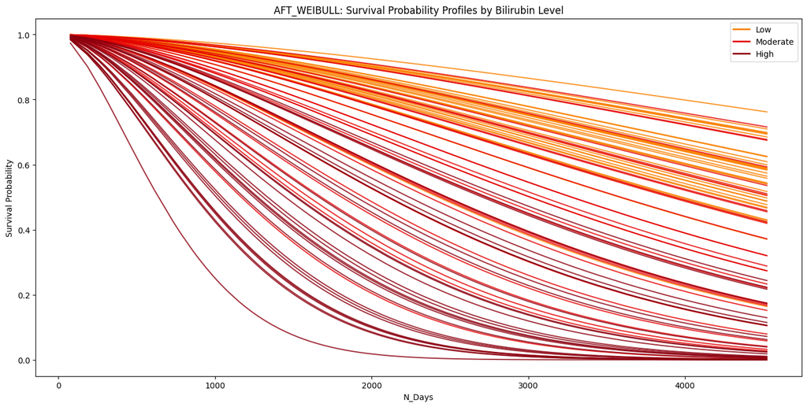

```python
##################################
# Plotting the individual
# survival probability profiles
# for the discretized Bilirubin predictor
##################################
cirrhosis_survival_test_modeling['Bilirubin_Level'] = pd.qcut(cirrhosis_survival_test_modeling['Bilirubin'], 3, labels=['Low','Moderate','High'])
plt.figure(figsize=(17, 8))
for bilirubin_level, color, label in zip(['Low', 'Moderate', 'High'], ['#FA8000','#E50000', '#8C000F'], ['Low', 'Moderate', 'High']):
    subset = cirrhosis_survival_test_modeling[cirrhosis_survival_test_modeling['Bilirubin_Level'] == bilirubin_level]
    for i, row in subset.iterrows():
        survival_function = cirrhosis_survival_aft_weibull.predict_survival_function(row)
        plt.plot(survival_function.index, survival_function.iloc[:, 0], c=color, alpha=0.8)
plt.title('AFT_WEIBULL: Survival Probability Profiles by Bilirubin Level')
plt.xlabel('N_Days')
plt.ylabel('Survival Probability')
low_patch = plt.Line2D([0], [0], color='#FA8000', lw=2, label='Low')
moderate_patch = plt.Line2D([0], [0], color='#E50000', lw=2, label='Moderate')
high_patch = plt.Line2D([0], [0], color='#8C000F', lw=2, label='High')
plt.legend(handles=[low_patch, moderate_patch, high_patch])
plt.show()
```

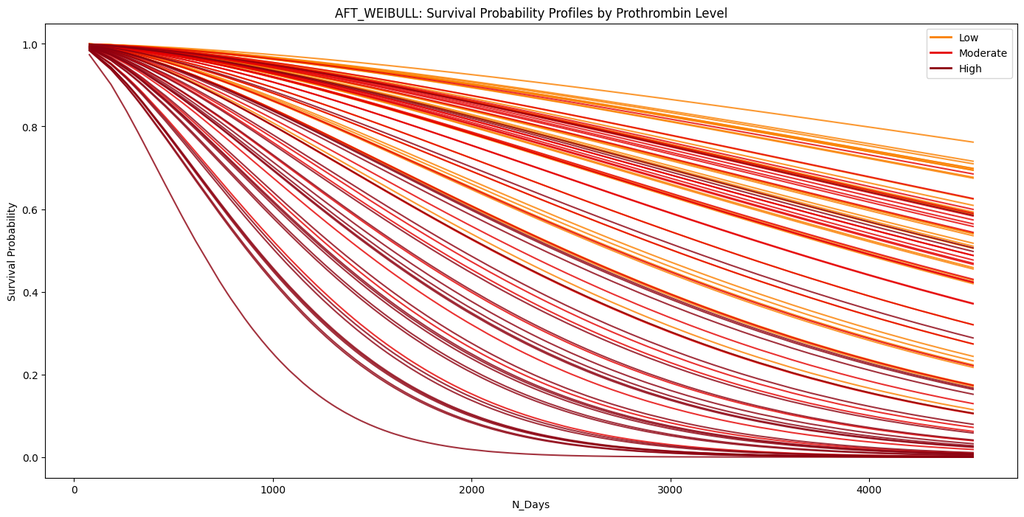

```python
##################################
# Plotting the individual
# survival probability profiles
# for the discretized Prothrombin predictor
##################################
cirrhosis_survival_test_modeling['Prothrombin_Level'] = pd.qcut(cirrhosis_survival_test_modeling['Prothrombin'], 3, labels=['Low','Moderate','High'])
plt.figure(figsize=(17, 8))
for prothrombin_level, color, label in zip(['Low', 'Moderate', 'High'], ['#FA8000','#E50000', '#8C000F'], ['Low', 'Moderate', 'High']):
    subset = cirrhosis_survival_test_modeling[cirrhosis_survival_test_modeling['Prothrombin_Level'] == prothrombin_level]
    for i, row in subset.iterrows():
        survival_function = cirrhosis_survival_aft_weibull.predict_survival_function(row)
        plt.plot(survival_function.index, survival_function.iloc[:, 0], c=color, alpha=0.8)
plt.title('AFT_WEIBULL: Survival Probability Profiles by Prothrombin Level')
plt.xlabel('N_Days')
plt.ylabel('Survival Probability')
low_patch = plt.Line2D([0], [0], color='#FA8000', lw=2, label='Low')
moderate_patch = plt.Line2D([0], [0], color='#E50000', lw=2, label='Moderate')
high_patch = plt.Line2D([0], [0], color='#8C000F', lw=2, label='High')
plt.legend(handles=[low_patch, moderate_patch, high_patch])
plt.show()
```

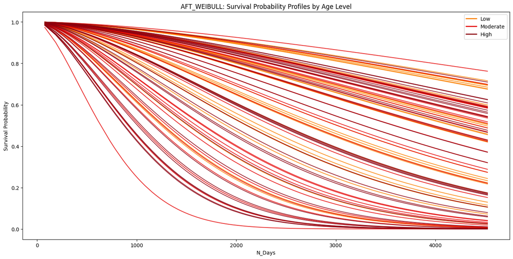

```python
##################################
# Plotting the individual
# survival probability profiles
# for the discretized Age predictor
##################################
cirrhosis_survival_test_modeling['Age_Level'] = pd.qcut(cirrhosis_survival_test_modeling['Age'], 3, labels=['Low','Moderate','High'])
plt.figure(figsize=(17, 8))
for age_level, color, label in zip(['Low', 'Moderate', 'High'], ['#FA8000','#E50000', '#8C000F'], ['Low', 'Moderate', 'High']):
    subset = cirrhosis_survival_test_modeling[cirrhosis_survival_test_modeling['Age_Level'] == age_level]
    for i, row in subset.iterrows():
        survival_function = cirrhosis_survival_aft_weibull.predict_survival_function(row)
        plt.plot(survival_function.index, survival_function.iloc[:, 0], c=color, alpha=0.8)
plt.title('AFT_WEIBULL: Survival Probability Profiles by Age Level')
plt.xlabel('N_Days')
plt.ylabel('Survival Probability')
low_patch = plt.Line2D([0], [0], color='#FA8000', lw=2, label='Low')
moderate_patch = plt.Line2D([0], [0], color='#E50000', lw=2, label='Moderate')
high_patch = plt.Line2D([0], [0], color='#8C000F', lw=2, label='High')
plt.legend(handles=[low_patch, moderate_patch, high_patch])
plt.show()
```

```python
##################################
# Defining a prediction function
# for SHAP value estimation
##################################
def aft_predict(fitter, df):
    return fitter.predict_expectation(df)

##################################
# Creating the explainer object
##################################
explainer_weibull = shap.Explainer(lambda x: aft_predict(cirrhosis_survival_aft_weibull,
                                                         pd.DataFrame(x, columns=cirrhosis_survival_train_modeling.columns[2:])),
                                   cirrhosis_survival_train_modeling.iloc[:, 2:])
shap_values_weibull = explainer_weibull(cirrhosis_survival_train_modeling.iloc[:, 2:])
```

```
PermutationExplainer explainer: 219it [00:25,  5.70it/s]
```

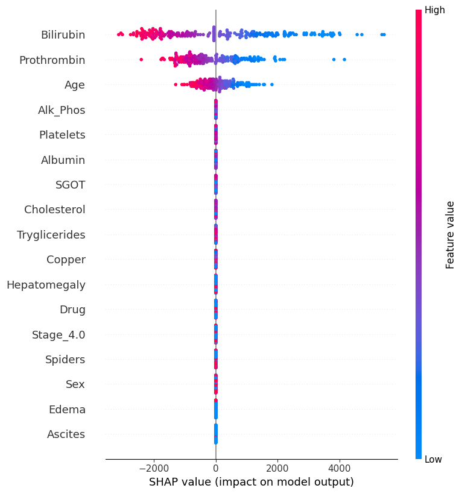

```python
##################################
# Plotting the SHAP summary plot
##################################
shap.summary_plot(shap_values_weibull,
                  cirrhosis_survival_train_modeling.iloc[:, 2:])
```

### 1.6.3 Log-Normal Accelerated Failure Time Model

[Survival Analysis](https://link.springer.com/book/10.1007/978-1-4419-6646-9/) deals with the analysis of time-to-event data. It focuses on the expected duration of time until one or more events of interest occur, such as death, failure, or relapse. This type of analysis is used to study and model the time until the occurrence of an event, taking into account that the event might not have occurred for all subjects during the study period. Several key aspects of survival analysis include the survival function which refers to the probability that an individual survives longer than a certain time, hazard function which describes the instantaneous rate at which events occur, given no prior event, and censoring pertaining to a condition where the event of interest has not occurred for some subjects during the observation period.

[Right-Censored Survival Data](https://link.springer.com/book/10.1007/978-1-4419-6646-9/) occurs when the event of interest has not happened for some subjects by the end of the study period or the last follow-up time. This type of censoring is common in survival analysis because not all individuals may experience the event before the study ends, or they might drop out or be lost to follow-up. Right-censored data is crucial in survival analysis as it allows the inclusion of all subjects in the analysis, providing more accurate and reliable estimates.

[Accelerated Failure Time Models](https://link.springer.com/book/10.1007/978-1-4419-6646-9/) are a class of survival analysis models used to analyze time-to-event data by directly modelling the survival time itself. An AFT model assumes that the effect of covariates accelerates or decelerates the life time of an event by some constant factor. The mathematical equation is represented by the logarithm of the survival time being equal to the sum of the vector of covariates multiplied to the vector of regression coefficients; and the product of the scale parameter and a random variable with a specified distribution. In an AFT model, the coefficients represent the multiplicative effect on the survival time. An exponentiated regression coefficient greater than one prolongs survival time, while a value less than one shortens it. The scale parameter determines the spread or variability of survival times. AFT models assume that the effect of covariates on survival time is multiplicative and that the survival times can be transformed to follow a specific distribution.

[Log-Normal Accelerated Failure Time Model](https://link.springer.com/book/10.1007/978-1-4419-6646-9/) assumes that the logarithm of survival time errors follows a normal distribution. The mathematical equation is represented by the logarithm of the survival time being equal to the sum of the vector of covariates multiplied to the vector of regression coefficients; and the product of the scale parameter and a standard normal error term. This model can be a good fit for data with a log-normal distribution, with well-established statistical properties and straightforward interpretation on the log scale. However, the model can have limited flexibility in hazard rate shapes compared to the Weibull model and can be less intuitive to interpret on the original time scale.

[Concordance Index](https://lifelines.readthedocs.io/en/latest/lifelines.utils.html) measures the model's ability to correctly order pairs of observations based on their predicted survival times. Values range from 0.5 to 1.0 indicating no predictive power (random guessing) and perfect predictions, respectively. As a metric, it provides a measure of discriminative ability and useful for ranking predictions. However, it does not provide information on the magnitude of errors and may be insensitive to the calibration of predicted survival probabilities.

[Mean Absolute Error](https://scikit-learn.org/stable/modules/generated/sklearn.metrics.mean_absolute_error.html) measures the average magnitude of the errors between predicted and actual survival times. Lower MAE values indicate better model performance, while reflecting the average prediction error in the same units as the survival time. As a metric, it is intuitive and easy to interpret while providing a direct measure of prediction accuracy. However, it may be sensitive to outliers and does not consider the probabilistic nature of survival predictions.

[Brier Score](https://scikit-learn.org/stable/modules/generated/sklearn.metrics.brier_score_loss.html) measures the accuracy of probabilistic predictions of survival at a specific time point. Values range from 0 to 1 with a lower brier scores indicating better accuracy. A Brier score of 0 indicates perfect predictions, while a score of 1 indicates the worst possible predictions. As a metric, it considers both discrimination and calibration, while reflecting the accuracy of predicted survival probabilities. However, it requires specifying a time point and aggregating scores over time points may be less interpretable.

1. The [log-normal accelerated failure time model](https://lifelines.readthedocs.io/en/latest/fitters/regression/LogNormalAFTFitter.html) from the **lifelines.LogNormalAFTFitter** Python library API was implemented.
2. The model implementation used 1 hyperparameter:
   - penalizer = penalty to the size of the coefficients during regression fixed at a value = 0.30
3. Only 5 of the 17 predictors, which were determined by the model as statistically significant, were used for prediction:
   - Edema: Presence associated with a decrease in time to event
   - Bilirubin: Increase in value associated with a decrease in time to event
   - Age: Increase in value associated with a decrease in time to event
   - Prothrombin: Increase in value associated with a decrease in time to event
   - Copper: Increase in value associated with a decrease in time to event
4. The cross-validated model performance of the model is summarized as follows:
   - **Concordance Index** = 0.8255
   - **Mean Absolute Error** = 2502.6369
   - **Brier Score** = 0.5425
5. The apparent model performance of the model is summarized as follows:
   - **Concordance Index** = 0.8413
   - **Mean Absolute Error** = 2518.3594
   - **Brier Score** = 0.5470
6. The independent test model performance of the model is summarized as follows:
   - **Concordance Index** = 0.8753
   - **Mean Absolute Error** = 1904.9879
   - **Brier Score** = 0.5775
7. Comparable apparent and cross-validated model performance was observed, indicative of the presence of minimal model overfitting.
8. The MAE for event observations were typically lower because the errors were directly tied to the observed event times, which are known and can be more accurately predicted. For censored observations, the prediction error reflects the model's inability to pinpoint the exact event time, leading to higher MAE due to the larger variability and the longer tail of potential event times beyond the censoring point.
9. Survival probability curves estimated for all cases. Shorter median survival times were observed for:
   - Event cases as compared to censored cases
   - Presence of Edema as compared to absence
   - Higher values for Bilirubin as compared to lower values
   - Higher values for Age as compared to lower values
   - Higher values for Prothrombin as compared to lower values
   - Higher values for Copper as compared to lower values
10. SHAP values were computed for the significant predictors, with contributions to the model output ranked as follows:
    - Higher values for Bilirubin result to the event expected to occur sooner
    - Higher values for Prothrombin result to the event expected to occur sooner
    - Higher values for Copper result to the event expected to occur sooner
    - Higher values for Age result to the event expected to occur sooner
    - Presence of Edema results to the event expected to occur sooner

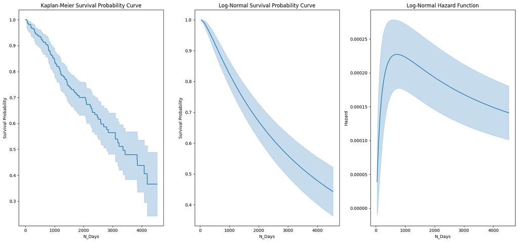

```python
##################################
# Assessing the survival probability
# and hazard function plots
# with a Log-Normal distribution
##################################
cirrhosis_survival_lognormal = LogNormalFitter()
cirrhosis_survival_lognormal.fit(durations=cirrhosis_survival_train_modeling['N_Days'],
                                 event_observed=cirrhosis_survival_train_modeling['Status'])

##################################
# Fitting a Kaplan-Meier estimation
##################################
cirrhosis_survival_km = KaplanMeierFitter()
cirrhosis_survival_km.fit(durations=cirrhosis_survival_train_modeling['N_Days'],
                          event_observed=cirrhosis_survival_train_modeling['Status'])

##################################
# Generating the survival probability
# and hazard function plots
##################################
plt.figure(figsize=(17, 8))

##################################
# Generating the Kaplan-Meier
# survival probability plot
##################################
plt.subplot(1, 3, 1)
cirrhosis_survival_km.plot_survival_function()
plt.title("Kaplan-Meier Survival Probability Curve")
plt.xlabel("N_Days")
plt.ylabel("Survival Probability")
plt.legend('',frameon=False)

##################################
# Generating the Weibull
# survival probability plot
##################################
plt.subplot(1, 3, 2)
cirrhosis_survival_lognormal.plot_survival_function()
plt.title("Log-Normal Survival Probability Curve")
plt.xlabel("N_Days")
plt.ylabel("Survival Probability")
plt.legend('',frameon=False)

##################################
# Generating the Weibull
# hazard function plot
##################################
plt.subplot(1, 3, 3)
cirrhosis_survival_lognormal.plot_hazard()
plt.title("Log-Normal Hazard Function")
plt.xlabel("N_Days")
plt.ylabel("Hazard")
plt.legend('',frameon=False)

##################################
# Consolidating all plots
##################################
plt.tight_layout()
plt.show()
```

```python
##################################
# Formulating the Accelerated Failure Time model
# based on a Log-Normal distribution
# and generating the summary
##################################
cirrhosis_survival_aft_lognormal = LogNormalAFTFitter(penalizer=0.30)
cirrhosis_survival_aft_lognormal.fit(cirrhosis_survival_train_modeling, duration_col='N_Days', event_col='Status')
cirrhosis_survival_aft_lognormal.print_summary()
```

| model | lifelines.LogNormalAFTFitter |
| --- | --- |
| duration col | 'N_Days' |
| event col | 'Status' |
| penalizer | 0.3 |
| number of observations | 218 |
| number of events observed | 87 |
| log-likelihood | -769.81 |
| time fit was run | 2024-10-14 07:42:04 UTC |

|  |  | coef | exp(coef) | se(coef) | coef lower 95% | coef upper 95% | exp(coef) lower 95% | exp(coef) upper 95% | cmp to | z | p | -log2(p) |
| --- | --- | --- | --- | --- | --- | --- | --- | --- | --- | --- | --- | --- |
| mu_ | Age | -0.18 | 0.83 | 0.07 | -0.32 | -0.05 | 0.73 | 0.95 | 0.00 | -2.62 | 0.01 | 6.85 |
|  | Albumin | 0.08 | 1.09 | 0.07 | -0.06 | 0.22 | 0.95 | 1.25 | 0.00 | 1.16 | 0.24 | 2.03 |
|  | Alk_Phos | -0.03 | 0.97 | 0.07 | -0.17 | 0.11 | 0.85 | 1.12 | 0.00 | -0.40 | 0.69 | 0.54 |
|  | Ascites | -0.33 | 0.72 | 0.25 | -0.81 | 0.16 | 0.44 | 1.17 | 0.00 | -1.32 | 0.19 | 2.43 |
|  | Bilirubin | -0.26 | 0.77 | 0.08 | -0.42 | -0.09 | 0.66 | 0.91 | 0.00 | -3.06 | <0.005 | 8.83 |
|  | Cholesterol | 0.01 | 1.01 | 0.07 | -0.13 | 0.16 | 0.88 | 1.17 | 0.00 | 0.18 | 0.86 | 0.22 |
|  | Copper | -0.16 | 0.85 | 0.07 | -0.30 | -0.01 | 0.74 | 0.99 | 0.00 | -2.12 | 0.03 | 4.89 |
|  | Drug | 0.09 | 1.10 | 0.13 | -0.16 | 0.35 | 0.85 | 1.42 | 0.00 | 0.70 | 0.48 | 1.05 |
|  | Edema | -0.37 | 0.69 | 0.18 | -0.73 | -0.01 | 0.48 | 0.99 | 0.00 | -2.04 | 0.04 | 4.60 |
|  | Hepatomegaly | -0.06 | 0.94 | 0.14 | -0.34 | 0.22 | 0.71 | 1.24 | 0.00 | -0.43 | 0.67 | 0.58 |
|  | Platelets | 0.08 | 1.08 | 0.07 | -0.06 | 0.21 | 0.94 | 1.24 | 0.00 | 1.11 | 0.27 | 1.92 |
|  | Prothrombin | -0.18 | 0.83 | 0.07 | -0.33 | -0.04 | 0.72 | 0.96 | 0.00 | -2.53 | 0.01 | 6.47 |
|  | SGOT | -0.09 | 0.91 | 0.07 | -0.23 | 0.05 | 0.79 | 1.05 | 0.00 | -1.24 | 0.22 | 2.21 |
|  | Sex | 0.04 | 1.04 | 0.19 | -0.32 | 0.40 | 0.72 | 1.49 | 0.00 | 0.21 | 0.83 | 0.26 |
|  | Spiders | -0.18 | 0.84 | 0.15 | -0.47 | 0.12 | 0.62 | 1.12 | 0.00 | -1.19 | 0.24 | 2.08 |
|  | Stage_4.0 | -0.26 | 0.77 | 0.15 | -0.57 | 0.04 | 0.57 | 1.04 | 0.00 | -1.70 | 0.09 | 3.50 |
|  | Tryglicerides | -0.09 | 0.92 | 0.07 | -0.23 | 0.05 | 0.80 | 1.05 | 0.00 | -1.24 | 0.22 | 2.21 |
|  | Intercept | 8.26 | 3879.36 | 0.21 | 7.86 | 8.67 | 2580.42 | 5832.16 | 0.00 | 39.72 | <0.005 | inf |
| sigma_ | Intercept | -0.14 | 0.87 | 0.07 | -0.28 | -0.01 | 0.76 | 0.99 | 0.00 | -2.15 | 0.03 | 5.00 |

| Concordance | 0.85 |
| --- | --- |
| AIC | 1577.63 |
| log-likelihood ratio test | 122.57 on 17 df |
| -log2(p) of ll-ratio test | 57.48 |

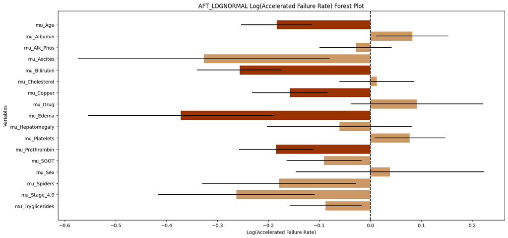

```python
##################################
# Plotting the log accelerated failure rate of the
# formulated Accelerated Failure Time model
# based on a Log-Normal distribution
##################################
cirrhosis_survival_aft_lognormal_summary = cirrhosis_survival_aft_lognormal.summary
cirrhosis_survival_aft_lognormal_summary_params = pd.DataFrame(cirrhosis_survival_aft_lognormal.params_)
significant = cirrhosis_survival_aft_lognormal_summary['p'] < 0.05
cirrhosis_survival_aft_lognormal_summary_log_accelerated_failure_rate = (list(cirrhosis_survival_aft_lognormal_summary_params.iloc[:,0].values))
plt.figure(figsize=(17, 8))
colors = ['#993300' if sig else '#CC9966' for sig in significant]

plt.barh([(index[0] + index[1]) for index in cirrhosis_survival_aft_lognormal_summary_params.index[0:17]],
         cirrhosis_survival_aft_lognormal_summary_log_accelerated_failure_rate[0:17],
         xerr=cirrhosis_survival_aft_lognormal_summary['se(coef)'][0:17],
         color=colors)
plt.xlabel('Log(Accelerated Failure Rate)')
plt.ylabel('Variables')
plt.title('AFT_LOGNORMAL Log(Accelerated Failure Rate) Forest Plot')
plt.axvline(x=0, color='k', linestyle='--')
plt.gca().invert_yaxis()
plt.show()
```

```python
##################################
# Determining the number of
# significant predictors
##################################
cirrhosis_survival_aft_lognormal_significant = sum(cirrhosis_survival_aft_lognormal_summary['p'] < 0.05)
display(f"Number of Significant Predictors: {cirrhosis_survival_aft_lognormal_significant-2}")
```

```
'Number of Significant Predictors: 5'
```

```python
##################################
# Formulating the Accelerated Failure Time model
# based on a Log-Normal distribution
# using the significant predictors only
# and generating the summary
##################################
feature_subset = ['Bilirubin','Prothrombin','Age','Copper','Edema','N_Days','Status']
cirrhosis_survival_aft_lognormal = LogNormalAFTFitter(penalizer=0.30)
cirrhosis_survival_aft_lognormal.fit(cirrhosis_survival_train_modeling[feature_subset], duration_col='N_Days', event_col='Status')
cirrhosis_survival_aft_lognormal.print_summary()
```

| model | lifelines.LogNormalAFTFitter |
| --- | --- |
| duration col | 'N_Days' |
| event col | 'Status' |
| penalizer | 0.3 |
| number of observations | 218 |
| number of events observed | 87 |
| log-likelihood | -779.28 |
| time fit was run | 2024-10-14 07:42:05 UTC |

|  |  | coef | exp(coef) | se(coef) | coef lower 95% | coef upper 95% | exp(coef) lower 95% | exp(coef) upper 95% | cmp to | z | p | -log2(p) |
| --- | --- | --- | --- | --- | --- | --- | --- | --- | --- | --- | --- | --- |
| mu_ | Age | -0.19 | 0.83 | 0.07 | -0.32 | -0.06 | 0.73 | 0.94 | 0.00 | -2.90 | <0.005 | 8.05 |
|  | Bilirubin | -0.37 | 0.69 | 0.07 | -0.52 | -0.23 | 0.60 | 0.79 | 0.00 | -5.10 | <0.005 | 21.51 |
|  | Copper | -0.22 | 0.80 | 0.07 | -0.36 | -0.08 | 0.70 | 0.93 | 0.00 | -3.02 | <0.005 | 8.61 |
|  | Edema | -0.56 | 0.57 | 0.17 | -0.90 | -0.21 | 0.41 | 0.81 | 0.00 | -3.19 | <0.005 | 9.47 |
|  | Prothrombin | -0.26 | 0.77 | 0.07 | -0.40 | -0.12 | 0.67 | 0.88 | 0.00 | -3.73 | <0.005 | 12.35 |
|  | Intercept | 8.18 | 3566.84 | 0.09 | 8.00 | 8.36 | 2978.10 | 4271.97 | 0.00 | 88.87 | <0.005 | inf |
| sigma_ | Intercept | -0.11 | 0.90 | 0.07 | -0.24 | 0.02 | 0.79 | 1.02 | 0.00 | -1.66 | 0.10 | 3.38 |

| Concordance | 0.84 |
| --- | --- |
| AIC | 1572.55 |
| log-likelihood ratio test | 103.65 on 5 df |
| -log2(p) of ll-ratio test | 66.59 |

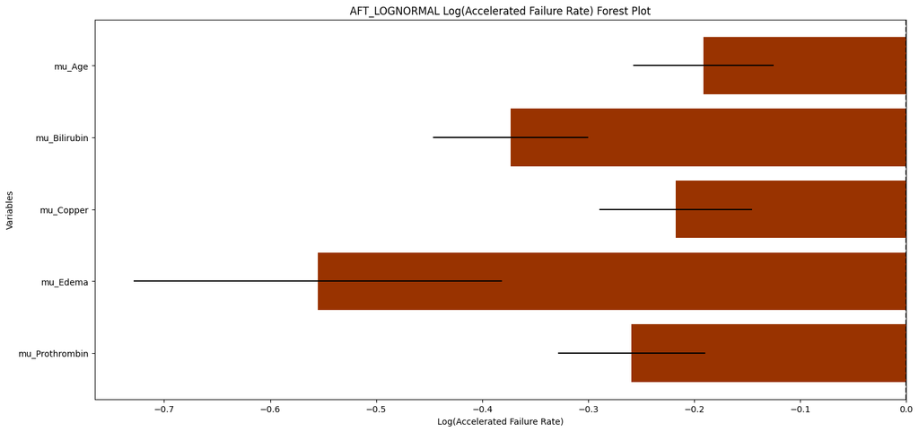

```python
##################################
# Plotting the log accelerated failure rate of the
# formulated Accelerated Failure Time model
# using the significant predictors only
# based on a Log-Normal distribution
##################################
cirrhosis_survival_aft_lognormal_summary = cirrhosis_survival_aft_lognormal.summary
cirrhosis_survival_aft_lognormal_summary_params = pd.DataFrame(cirrhosis_survival_aft_lognormal.params_)
significant = cirrhosis_survival_aft_lognormal_summary['p'] < 0.05
cirrhosis_survival_aft_lognormal_summary_log_accelerated_failure_rate = (list(cirrhosis_survival_aft_lognormal_summary_params.iloc[:,0].values))
plt.figure(figsize=(17, 8))
colors = ['#993300' if sig else '#CC9966' for sig in significant]

plt.barh([(index[0] + index[1]) for index in cirrhosis_survival_aft_lognormal_summary_params.index[0:5]],
         cirrhosis_survival_aft_lognormal_summary_log_accelerated_failure_rate[0:5],
         xerr=cirrhosis_survival_aft_lognormal_summary['se(coef)'][0:5],
         color=colors)
plt.xlabel('Log(Accelerated Failure Rate)')
plt.ylabel('Variables')
plt.title('AFT_LOGNORMAL Log(Accelerated Failure Rate) Forest Plot')
plt.axvline(x=0, color='k', linestyle='--')
plt.gca().invert_yaxis()
plt.show()
```

```python
##################################
# Gathering the apparent model performance
# as baseline for evaluating overfitting
##################################
cirrhosis_survival_aft_lognormal.fit(cirrhosis_survival_train_modeling[feature_subset], duration_col='N_Days', event_col='Status')
train_predictions = cirrhosis_survival_aft_lognormal.predict_median(cirrhosis_survival_train_modeling)
cirrhosis_survival_aft_lognormal_train_ci = concordance_index(cirrhosis_survival_train_modeling['N_Days'],
                                                            train_predictions,
                                                            cirrhosis_survival_train_modeling['Status'])
time_point = cirrhosis_survival_train_modeling['N_Days'].median()
cirrhosis_survival_aft_lognormal_train_mae = mean_absolute_error(cirrhosis_survival_train_modeling['N_Days'], train_predictions)
cirrhosis_survival_aft_lognormal_train_brier = brier_score_loss(cirrhosis_survival_train_modeling['Status'],
                                                              cirrhosis_survival_aft_lognormal.predict_survival_function(cirrhosis_survival_train_modeling,
                                                                                                                       times=[time_point]).T[time_point])
display(f"Apparent Concordance Index: {cirrhosis_survival_aft_lognormal_train_ci}")
display(f"Apparent MAE: {cirrhosis_survival_aft_lognormal_train_mae}")
display(f"Apparent Brier Score: {cirrhosis_survival_aft_lognormal_train_brier}")
```

```
'Apparent Concordance Index: 0.8413524057217165'
```

```
'Apparent MAE: 2518.3593852441572'
```

```
'Apparent Brier Score: 0.5470406779352227'
```

```python
##################################
# Performing 5-Fold Cross-Validation
# on the training data
##################################
kf = KFold(n_splits=5, shuffle=True, random_state=88888888)
ci_scores = []
mae_scores = []
brier_scores = []

for train_index, val_index in kf.split(cirrhosis_survival_train_modeling):
    df_train_fold = cirrhosis_survival_train_modeling.iloc[train_index]
    df_val_fold = cirrhosis_survival_train_modeling.iloc[val_index]

    cirrhosis_survival_aft_lognormal.fit(df_train_fold[feature_subset], duration_col='N_Days', event_col='Status')
    val_predictions = cirrhosis_survival_aft_lognormal.predict_median(df_val_fold)
    time_point = df_val_fold['N_Days'].median()
    ci = concordance_index(df_val_fold['N_Days'], val_predictions, df_val_fold['Status'])
    mae = mean_absolute_error(df_val_fold['N_Days'], val_predictions)
    brier = brier_score_loss(df_val_fold['Status'],
                             cirrhosis_survival_aft_lognormal.predict_survival_function(df_val_fold,
                                                                                      times=[time_point]).T[time_point])
    ci_scores.append(ci)
    mae_scores.append(mae)
    brier_scores.append(brier)

cirrhosis_survival_aft_lognormal_cv_ci_mean = np.mean(ci_scores)
cirrhosis_survival_aft_lognormal_cv_ci_std = np.std(ci_scores)
cirrhosis_survival_aft_lognormal_cv_mae_mean = np.mean(mae_scores)
cirrhosis_survival_aft_lognormal_cv_brier_mean = np.mean(brier_scores)

display(f"Cross-Validated Concordance Index: {cirrhosis_survival_aft_lognormal_cv_ci_mean}")
display(f"Cross-Validated MAE: {cirrhosis_survival_aft_lognormal_cv_mae_mean}")
display(f"Cross-Validated Brier Score: {cirrhosis_survival_aft_lognormal_cv_brier_mean}")
```

```
'Cross-Validated Concordance Index: 0.8255764006037584'
```

```
'Cross-Validated MAE: 2502.6369548831367'
```

```
'Cross-Validated Brier Score: 0.5425832599120203'
```

```python
##################################
# Evaluating the model performance
# on test data
##################################
test_predictions = cirrhosis_survival_aft_lognormal.predict_median(cirrhosis_survival_test_modeling)
cirrhosis_survival_aft_lognormal_test_ci = concordance_index(cirrhosis_survival_test_modeling['N_Days'],
                                                           test_predictions,
                                                           cirrhosis_survival_test_modeling['Status'])
time_point = cirrhosis_survival_test_modeling['N_Days'].median()
cirrhosis_survival_aft_lognormal_test_mae = mean_absolute_error(cirrhosis_survival_test_modeling['N_Days'], test_predictions)
cirrhosis_survival_aft_lognormal_test_brier = brier_score_loss(cirrhosis_survival_test_modeling['Status'],
                                                              cirrhosis_survival_aft_lognormal.predict_survival_function(cirrhosis_survival_test_modeling,
                                                                                                                       times=[time_point]).T[time_point])
display(f"Apparent Concordance Index: {cirrhosis_survival_aft_lognormal_test_ci}")
display(f"Apparent MAE: {cirrhosis_survival_aft_lognormal_test_mae}")
display(f"Apparent Brier Score: {cirrhosis_survival_aft_lognormal_test_brier}")
```

```
'Apparent Concordance Index: 0.8752834467120182'
```

```
'Apparent MAE: 1904.9879866903511'
```

```
'Apparent Brier Score: 0.5775019785104171'
```

```python
##################################
# Gathering the model performance metrics
# from training, cross-validation and test
##################################
aft_lognormal_set = pd.DataFrame(["Train","Cross-Validation","Test"]*3)
aft_lognormal_metric = pd.DataFrame((["Concordance.Index"]*3) + (["MAE"]*3) + (["Brier.Score"]*3))
aft_lognormal_metric_values = pd.DataFrame([cirrhosis_survival_aft_lognormal_train_ci,
                                           cirrhosis_survival_aft_lognormal_cv_ci_mean,
                                           cirrhosis_survival_aft_lognormal_test_ci,
                                           cirrhosis_survival_aft_lognormal_train_mae,
                                           cirrhosis_survival_aft_lognormal_cv_mae_mean,
                                           cirrhosis_survival_aft_lognormal_test_mae,
                                           cirrhosis_survival_aft_lognormal_train_brier,
                                           cirrhosis_survival_aft_lognormal_cv_brier_mean,
                                           cirrhosis_survival_aft_lognormal_test_brier])
aft_lognormal_method = pd.DataFrame(["AFT_LOGNORMAL"]*9)
aft_lognormal_summary = pd.concat([aft_lognormal_set,
                                       aft_lognormal_metric,
                                       aft_lognormal_metric_values,
                                       aft_lognormal_method],
                                      axis=1)
aft_lognormal_summary.columns = ['Set', 'Metric', 'Value', 'Method']
aft_lognormal_summary.reset_index(inplace=True, drop=True)
display(aft_lognormal_summary)
```

|  | Set | Metric | Value | Method |
| --- | --- | --- | --- | --- |
| 0 | Train | Concordance.Index | 0.841352 | AFT_LOGNORMAL |
| 1 | Cross-Validation | Concordance.Index | 0.825576 | AFT_LOGNORMAL |
| 2 | Test | Concordance.Index | 0.875283 | AFT_LOGNORMAL |
| 3 | Train | MAE | 2518.359385 | AFT_LOGNORMAL |
| 4 | Cross-Validation | MAE | 2502.636955 | AFT_LOGNORMAL |
| 5 | Test | MAE | 1904.987987 | AFT_LOGNORMAL |
| 6 | Train | Brier.Score | 0.547041 | AFT_LOGNORMAL |
| 7 | Cross-Validation | Brier.Score | 0.542583 | AFT_LOGNORMAL |
| 8 | Test | Brier.Score | 0.577502 | AFT_LOGNORMAL |

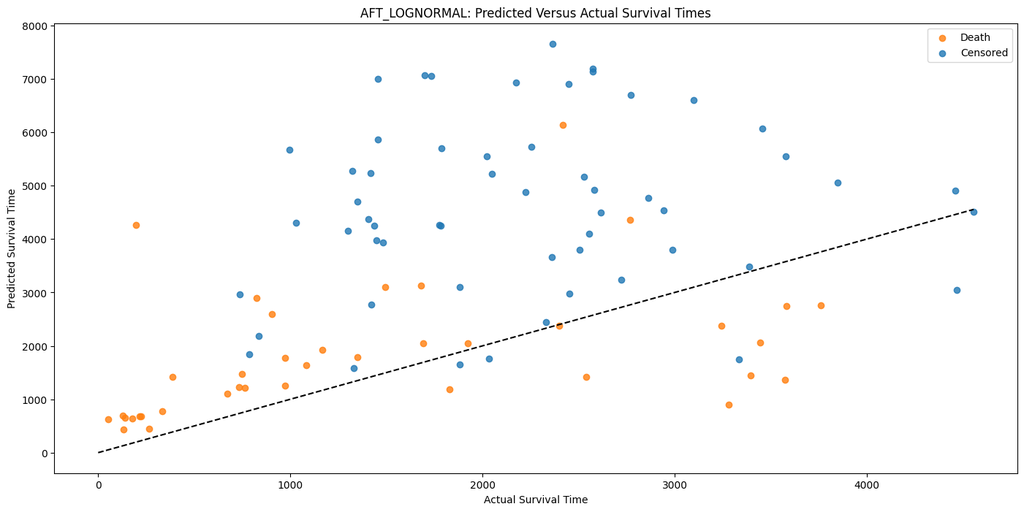

```python
##################################
# Evaluating the predicted
# and actual survival times
##################################
predicted_survival_times = cirrhosis_survival_aft_lognormal.predict_median(cirrhosis_survival_test_modeling)
fig, ax = plt.subplots(figsize=(17, 8))
for status, color, label in zip([True, False], ['#FF7F0E','#1F77B4'], ['Death', 'Censored']):
    subset = cirrhosis_survival_test_modeling[cirrhosis_survival_test_modeling['Status'] == status]
    ax.scatter(subset['N_Days'], predicted_survival_times.iloc[subset.index], c=color, label=label, alpha=0.8)
ax.set_xlabel('Actual Survival Time')
ax.set_ylabel('Predicted Survival Time')
ax.set_title('AFT_LOGNORMAL: Predicted Versus Actual Survival Times')
ax.legend()
plt.plot([0, cirrhosis_survival_test_modeling['N_Days'].max()],
         [0, cirrhosis_survival_test_modeling['N_Days'].max()],
         color='black', linestyle='--')
plt.show()
```

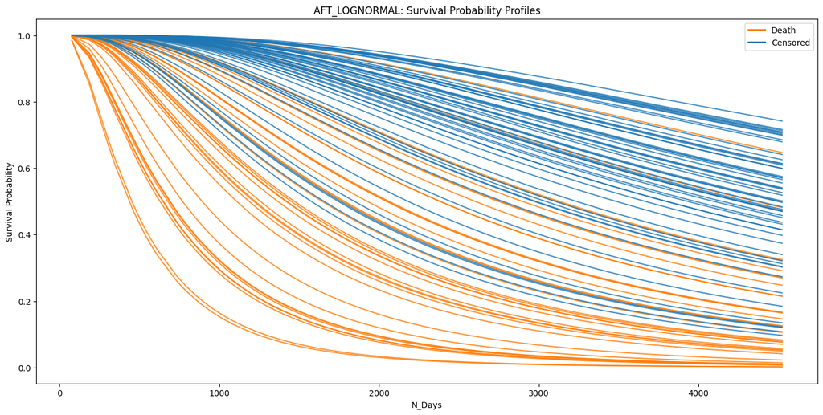

```python
##################################
# Plotting the individual
# survival probability profiles
##################################
plt.figure(figsize=(17, 8))
for status, color, label in zip([True, False], ['#FF7F0E','#1F77B4'], ['Death', 'Censored']):
    subset = cirrhosis_survival_test_modeling[cirrhosis_survival_test_modeling['Status'] == status]
    for i, row in subset.iterrows():
        survival_function = cirrhosis_survival_aft_lognormal.predict_survival_function(row)
        plt.plot(survival_function.index, survival_function.iloc[:, 0], c=color, alpha=0.8)
plt.title('AFT_LOGNORMAL: Survival Probability Profiles')
plt.xlabel('N_Days')
plt.ylabel('Survival Probability')
death_patch = plt.Line2D([0], [0], color='#FF7F0E', lw=2, label='Death')
censored_patch = plt.Line2D([0], [0], color='#1F77B4', lw=2, label='Censored')
plt.legend(handles=[death_patch, censored_patch])
plt.show()
```

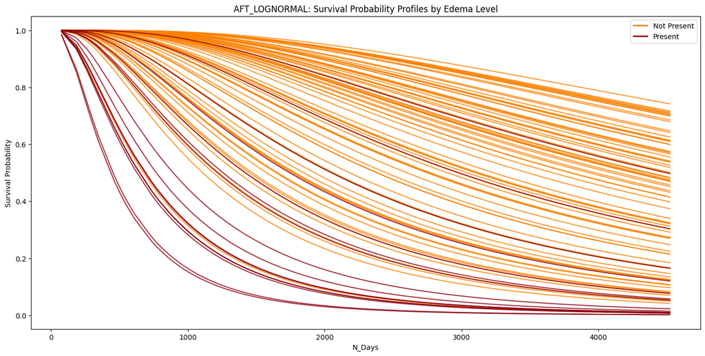

```python
##################################
# Plotting the individual
# survival probability profiles
# for the discretized Edema predictor
##################################
plt.figure(figsize=(17, 8))
for edema_level, color, label in zip([0, 1], ['#FA8000', '#8C000F'], ['Not Present', 'Present']):
    subset = cirrhosis_survival_test_modeling[cirrhosis_survival_test_modeling['Edema'] == edema_level]
    for i, row in subset.iterrows():
        survival_function = cirrhosis_survival_aft_lognormal.predict_survival_function(row)
        plt.plot(survival_function.index, survival_function.iloc[:, 0], c=color, alpha=0.8)
plt.title('AFT_LOGNORMAL: Survival Probability Profiles by Edema Level')
plt.xlabel('N_Days')
plt.ylabel('Survival Probability')
not_present_patch = plt.Line2D([0], [0], color='#FA8000', lw=2, label='Not Present')
present_patch = plt.Line2D([0], [0], color='#8C000F', lw=2, label='Present')
plt.legend(handles=[not_present_patch, present_patch])
plt.show()
```

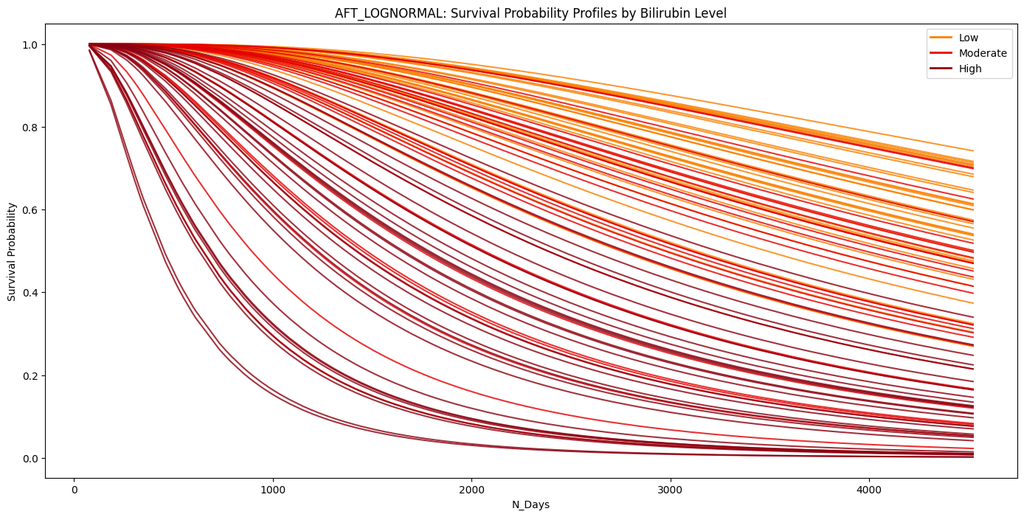

```python
##################################
# Plotting the individual
# survival probability profiles
# for the discretized Bilirubin predictor
##################################
cirrhosis_survival_test_modeling['Bilirubin_Level'] = pd.qcut(cirrhosis_survival_test_modeling['Bilirubin'], 3, labels=['Low','Moderate','High'])
plt.figure(figsize=(17, 8))
for bilirubin_level, color, label in zip(['Low', 'Moderate', 'High'], ['#FA8000','#E50000', '#8C000F'], ['Low', 'Moderate', 'High']):
    subset = cirrhosis_survival_test_modeling[cirrhosis_survival_test_modeling['Bilirubin_Level'] == bilirubin_level]
    for i, row in subset.iterrows():
        survival_function = cirrhosis_survival_aft_lognormal.predict_survival_function(row)
        plt.plot(survival_function.index, survival_function.iloc[:, 0], c=color, alpha=0.8)
plt.title('AFT_LOGNORMAL: Survival Probability Profiles by Bilirubin Level')
plt.xlabel('N_Days')
plt.ylabel('Survival Probability')
low_patch = plt.Line2D([0], [0], color='#FA8000', lw=2, label='Low')
moderate_patch = plt.Line2D([0], [0], color='#E50000', lw=2, label='Moderate')
high_patch = plt.Line2D([0], [0], color='#8C000F', lw=2, label='High')
plt.legend(handles=[low_patch, moderate_patch, high_patch])
plt.show()
```

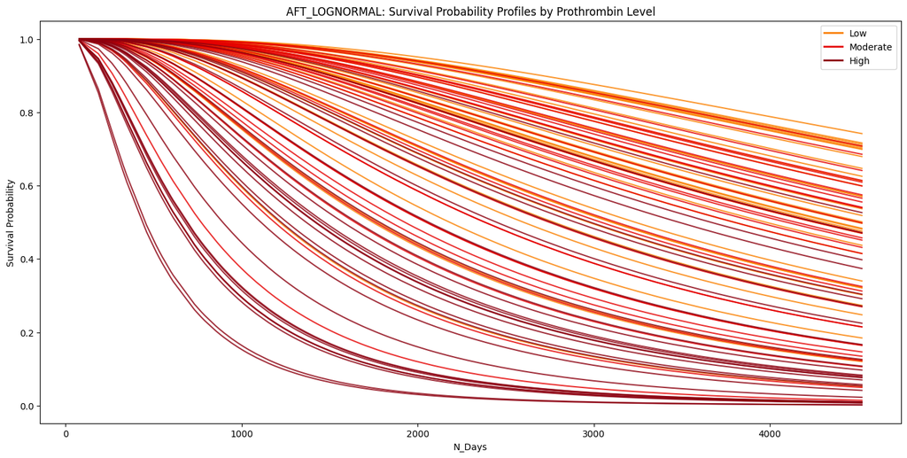

```python
##################################
# Plotting the individual
# survival probability profiles
# for the discretized Prothrombin predictor
##################################
cirrhosis_survival_test_modeling['Prothrombin_Level'] = pd.qcut(cirrhosis_survival_test_modeling['Prothrombin'], 3, labels=['Low','Moderate','High'])
plt.figure(figsize=(17, 8))
for prothrombin_level, color, label in zip(['Low', 'Moderate', 'High'], ['#FA8000','#E50000', '#8C000F'], ['Low', 'Moderate', 'High']):
    subset = cirrhosis_survival_test_modeling[cirrhosis_survival_test_modeling['Prothrombin_Level'] == prothrombin_level]
    for i, row in subset.iterrows():
        survival_function = cirrhosis_survival_aft_lognormal.predict_survival_function(row)
        plt.plot(survival_function.index, survival_function.iloc[:, 0], c=color, alpha=0.8)
plt.title('AFT_LOGNORMAL: Survival Probability Profiles by Prothrombin Level')
plt.xlabel('N_Days')
plt.ylabel('Survival Probability')
low_patch = plt.Line2D([0], [0], color='#FA8000', lw=2, label='Low')
moderate_patch = plt.Line2D([0], [0], color='#E50000', lw=2, label='Moderate')
high_patch = plt.Line2D([0], [0], color='#8C000F', lw=2, label='High')
plt.legend(handles=[low_patch, moderate_patch, high_patch])
plt.show()
```

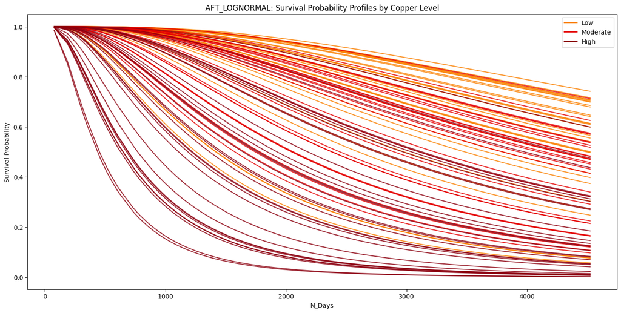

```python
##################################
# Plotting the individual
# survival probability profiles
# for the discretized Copper predictor
##################################
cirrhosis_survival_test_modeling['Copper_Level'] = pd.qcut(cirrhosis_survival_test_modeling['Copper'], 3, labels=['Low','Moderate','High'])
plt.figure(figsize=(17, 8))
for copper_level, color, label in zip(['Low', 'Moderate', 'High'], ['#FA8000','#E50000', '#8C000F'], ['Low', 'Moderate', 'High']):
    subset = cirrhosis_survival_test_modeling[cirrhosis_survival_test_modeling['Copper_Level'] == copper_level]
    for i, row in subset.iterrows():
        survival_function = cirrhosis_survival_aft_lognormal.predict_survival_function(row)
        plt.plot(survival_function.index, survival_function.iloc[:, 0], c=color, alpha=0.8)
plt.title('AFT_LOGNORMAL: Survival Probability Profiles by Copper Level')
plt.xlabel('N_Days')
plt.ylabel('Survival Probability')
low_patch = plt.Line2D([0], [0], color='#FA8000', lw=2, label='Low')
moderate_patch = plt.Line2D([0], [0], color='#E50000', lw=2, label='Moderate')
high_patch = plt.Line2D([0], [0], color='#8C000F', lw=2, label='High')
plt.legend(handles=[low_patch, moderate_patch, high_patch])
plt.show()
```

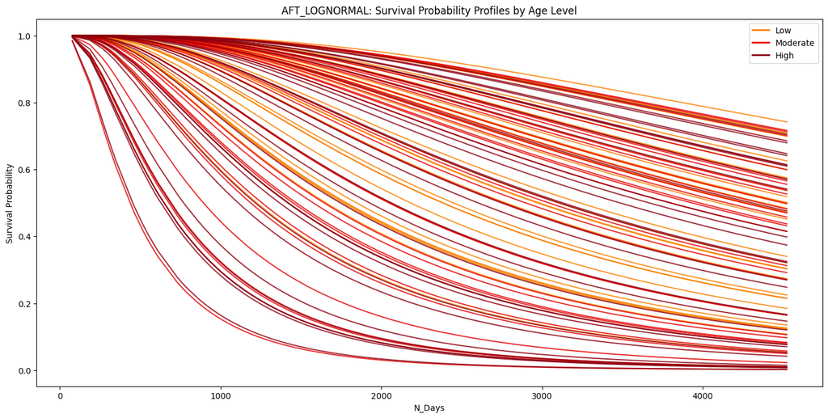

```python
##################################
# Plotting the individual
# survival probability profiles
# for the discretized Age predictor
##################################
cirrhosis_survival_test_modeling['Age_Level'] = pd.qcut(cirrhosis_survival_test_modeling['Age'], 3, labels=['Low','Moderate','High'])
plt.figure(figsize=(17, 8))
for age_level, color, label in zip(['Low', 'Moderate', 'High'], ['#FA8000','#E50000', '#8C000F'], ['Low', 'Moderate', 'High']):
    subset = cirrhosis_survival_test_modeling[cirrhosis_survival_test_modeling['Age_Level'] == age_level]
    for i, row in subset.iterrows():
        survival_function = cirrhosis_survival_aft_lognormal.predict_survival_function(row)
        plt.plot(survival_function.index, survival_function.iloc[:, 0], c=color, alpha=0.8)
plt.title('AFT_LOGNORMAL: Survival Probability Profiles by Age Level')
plt.xlabel('N_Days')
plt.ylabel('Survival Probability')
low_patch = plt.Line2D([0], [0], color='#FA8000', lw=2, label='Low')
moderate_patch = plt.Line2D([0], [0], color='#E50000', lw=2, label='Moderate')
high_patch = plt.Line2D([0], [0], color='#8C000F', lw=2, label='High')
plt.legend(handles=[low_patch, moderate_patch, high_patch])
plt.show()
```

```python
##################################
# Defining a prediction function
# for SHAP value estimation
##################################
def aft_predict(fitter, df):
    return fitter.predict_expectation(df)

##################################
# Creating the explainer object
##################################
explainer_lognormal = shap.Explainer(lambda x: aft_predict(cirrhosis_survival_aft_lognormal,
                                                         pd.DataFrame(x, columns=cirrhosis_survival_train_modeling.columns[2:])),
                                   cirrhosis_survival_train_modeling.iloc[:, 2:])
shap_values_lognormal = explainer_lognormal(cirrhosis_survival_train_modeling.iloc[:, 2:])
```

```
PermutationExplainer explainer: 219it [00:21,  5.49it/s]
```

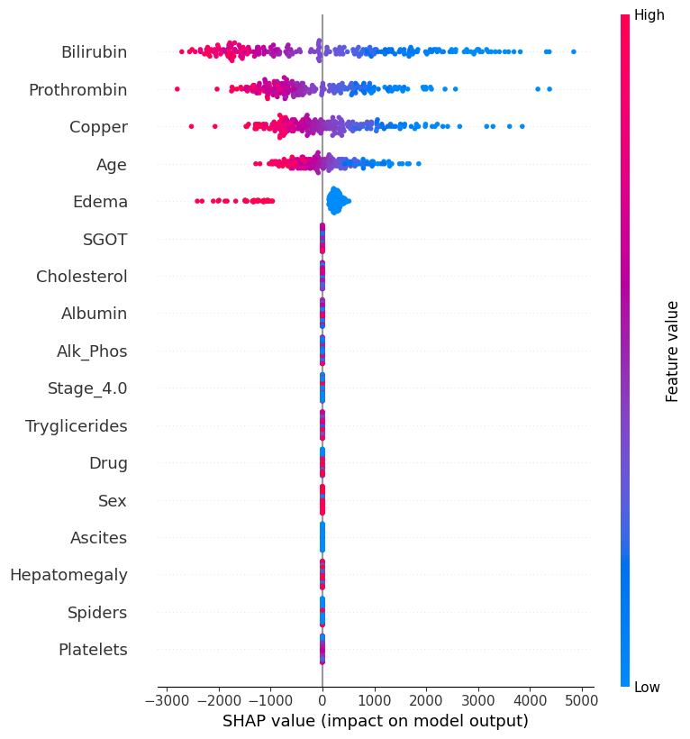

```python
##################################
# Plotting the SHAP summary plot
##################################
shap.summary_plot(shap_values_lognormal,
                  cirrhosis_survival_train_modeling.iloc[:, 2:])
```

### 1.6.4 Log-Logistic Accelerated Failure Time Model

[Survival Analysis](https://link.springer.com/book/10.1007/978-1-4419-6646-9/) deals with the analysis of time-to-event data. It focuses on the expected duration of time until one or more events of interest occur, such as death, failure, or relapse. This type of analysis is used to study and model the time until the occurrence of an event, taking into account that the event might not have occurred for all subjects during the study period. Several key aspects of survival analysis include the survival function which refers to the probability that an individual survives longer than a certain time, hazard function which describes the instantaneous rate at which events occur, given no prior event, and censoring pertaining to a condition where the event of interest has not occurred for some subjects during the observation period.

[Right-Censored Survival Data](https://link.springer.com/book/10.1007/978-1-4419-6646-9/) occurs when the event of interest has not happened for some subjects by the end of the study period or the last follow-up time. This type of censoring is common in survival analysis because not all individuals may experience the event before the study ends, or they might drop out or be lost to follow-up. Right-censored data is crucial in survival analysis as it allows the inclusion of all subjects in the analysis, providing more accurate and reliable estimates.

[Accelerated Failure Time Models](https://link.springer.com/book/10.1007/978-1-4419-6646-9/) are a class of survival analysis models used to analyze time-to-event data by directly modelling the survival time itself. An AFT model assumes that the effect of covariates accelerates or decelerates the life time of an event by some constant factor. The mathematical equation is represented by the logarithm of the survival time being equal to the sum of the vector of covariates multiplied to the vector of regression coefficients; and the product of the scale parameter and a random variable with a specified distribution. In an AFT model, the coefficients represent the multiplicative effect on the survival time. An exponentiated regression coefficient greater than one prolongs survival time, while a value less than one shortens it. The scale parameter determines the spread or variability of survival times. AFT models assume that the effect of covariates on survival time is multiplicative and that the survival times can be transformed to follow a specific distribution.

[Log-Logistic Accelerated Failure Time Model](https://link.springer.com/book/10.1007/978-1-4419-6646-9/) assumes that the survival time errors follow a log-logistic distribution. The mathematical equation is represented by the logarithm of the survival time being equal to the sum of the vector of covariates multiplied to the vector of regression coefficients; and the product of the scale parameter and a standard logistic error term. This model can estimate various hazard shapes, including non-monotonic hazard functions and may be more flexible than the Log Normal model. However, interpretation of results can be complex due to the nature of the logistic distribution and the model structure may be less robust to outliers compared to other models.

[Concordance Index](https://lifelines.readthedocs.io/en/latest/lifelines.utils.html) measures the model's ability to correctly order pairs of observations based on their predicted survival times. Values range from 0.5 to 1.0 indicating no predictive power (random guessing) and perfect predictions, respectively. As a metric, it provides a measure of discriminative ability and useful for ranking predictions. However, it does not provide information on the magnitude of errors and may be insensitive to the calibration of predicted survival probabilities.

[Mean Absolute Error](https://scikit-learn.org/stable/modules/generated/sklearn.metrics.mean_absolute_error.html) measures the average magnitude of the errors between predicted and actual survival times. Lower MAE values indicate better model performance, while reflecting the average prediction error in the same units as the survival time. As a metric, it is intuitive and easy to interpret while providing a direct measure of prediction accuracy. However, it may be sensitive to outliers and does not consider the probabilistic nature of survival predictions.

[Brier Score](https://scikit-learn.org/stable/modules/generated/sklearn.metrics.brier_score_loss.html) measures the accuracy of probabilistic predictions of survival at a specific time point. Values range from 0 to 1 with a lower brier scores indicating better accuracy. A Brier score of 0 indicates perfect predictions, while a score of 1 indicates the worst possible predictions. As a metric, it considers both discrimination and calibration, while reflecting the accuracy of predicted survival probabilities. However, it requires specifying a time point and aggregating scores over time points may be less interpretable.

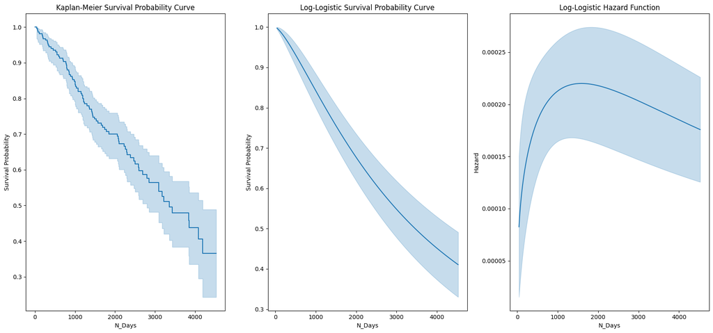

```python
##################################
# Assessing the survival probability
# and hazard function plots
# with a Log-Logistic distribution
##################################
cirrhosis_survival_loglogistic = LogLogisticFitter()
cirrhosis_survival_loglogistic.fit(durations=cirrhosis_survival_train_modeling['N_Days'],
                                   event_observed=cirrhosis_survival_train_modeling['Status'])

##################################
# Fitting a Kaplan-Meier estimation
##################################
cirrhosis_survival_km = KaplanMeierFitter()
cirrhosis_survival_km.fit(durations=cirrhosis_survival_train_modeling['N_Days'],
                          event_observed=cirrhosis_survival_train_modeling['Status'])

##################################
# Generating the survival probability
# and hazard function plots
##################################
plt.figure(figsize=(17, 8))

##################################
# Generating the Kaplan-Meier
# survival probability plot
##################################
plt.subplot(1, 3, 1)
cirrhosis_survival_km.plot_survival_function()
plt.title("Kaplan-Meier Survival Probability Curve")
plt.xlabel("N_Days")
plt.ylabel("Survival Probability")
plt.legend('',frameon=False)

##################################
# Generating the Log-Logistic
# survival probability plot
##################################
plt.subplot(1, 3, 2)
cirrhosis_survival_loglogistic.plot_survival_function()
plt.title("Log-Logistic Survival Probability Curve")
plt.xlabel("N_Days")
plt.ylabel("Survival Probability")
plt.legend('',frameon=False)

##################################
# Generating the log-Logistic
# hazard function plot
##################################
plt.subplot(1, 3, 3)
cirrhosis_survival_loglogistic.plot_hazard()
plt.title("Log-Logistic Hazard Function")
plt.xlabel("N_Days")
plt.ylabel("Hazard")
plt.legend('',frameon=False)

##################################
# Consolidating all plots
##################################
plt.tight_layout()
plt.show()
```

```python
##################################
# Formulating the Accelerated Failure Time model
# based on a Log-Logistic distribution
# and generating the summary
##################################
cirrhosis_survival_aft_loglogistic = LogLogisticAFTFitter(penalizer=0.30)
cirrhosis_survival_aft_loglogistic.fit(cirrhosis_survival_train_modeling, duration_col='N_Days', event_col='Status')
cirrhosis_survival_aft_loglogistic.print_summary()
```

| model | lifelines.LogLogisticAFTFitter |
| --- | --- |
| duration col | 'N_Days' |
| event col | 'Status' |
| penalizer | 0.3 |
| number of observations | 218 |
| number of events observed | 87 |
| log-likelihood | -781.35 |
| time fit was run | 2024-10-14 07:42:37 UTC |

|  |  | coef | exp(coef) | se(coef) | coef lower 95% | coef upper 95% | exp(coef) lower 95% | exp(coef) upper 95% | cmp to | z | p | -log2(p) |
| --- | --- | --- | --- | --- | --- | --- | --- | --- | --- | --- | --- | --- |
| alpha_ | Age | -0.18 | 0.83 | 0.08 | -0.33 | -0.04 | 0.72 | 0.97 | 0.00 | -2.42 | 0.02 | 6.02 |
|  | Albumin | 0.10 | 1.10 | 0.08 | -0.05 | 0.25 | 0.95 | 1.29 | 0.00 | 1.27 | 0.20 | 2.30 |
|  | Alk_Phos | -0.05 | 0.95 | 0.08 | -0.20 | 0.11 | 0.82 | 1.11 | 0.00 | -0.60 | 0.55 | 0.87 |
|  | Ascites | -0.29 | 0.75 | 0.28 | -0.83 | 0.25 | 0.43 | 1.28 | 0.00 | -1.06 | 0.29 | 1.79 |
|  | Bilirubin | -0.27 | 0.77 | 0.09 | -0.44 | -0.09 | 0.64 | 0.91 | 0.00 | -3.00 | <0.005 | 8.55 |
|  | Cholesterol | 0.00 | 1.00 | 0.08 | -0.15 | 0.16 | 0.86 | 1.17 | 0.00 | 0.04 | 0.97 | 0.05 |
|  | Copper | -0.16 | 0.85 | 0.08 | -0.32 | -0.01 | 0.73 | 0.99 | 0.00 | -2.05 | 0.04 | 4.64 |
|  | Drug | 0.09 | 1.10 | 0.14 | -0.19 | 0.38 | 0.83 | 1.46 | 0.00 | 0.66 | 0.51 | 0.98 |
|  | Edema | -0.33 | 0.72 | 0.20 | -0.73 | 0.06 | 0.48 | 1.07 | 0.00 | -1.65 | 0.10 | 3.32 |
|  | Hepatomegaly | -0.10 | 0.90 | 0.15 | -0.40 | 0.20 | 0.67 | 1.22 | 0.00 | -0.66 | 0.51 | 0.97 |
|  | Platelets | 0.08 | 1.09 | 0.08 | -0.07 | 0.23 | 0.94 | 1.26 | 0.00 | 1.09 | 0.27 | 1.87 |
|  | Prothrombin | -0.20 | 0.82 | 0.08 | -0.35 | -0.04 | 0.70 | 0.96 | 0.00 | -2.52 | 0.01 | 6.41 |
|  | SGOT | -0.09 | 0.91 | 0.08 | -0.25 | 0.06 | 0.78 | 1.06 | 0.00 | -1.19 | 0.23 | 2.09 |
|  | Sex | 0.11 | 1.12 | 0.20 | -0.29 | 0.51 | 0.75 | 1.66 | 0.00 | 0.55 | 0.59 | 0.77 |
|  | Spiders | -0.15 | 0.86 | 0.17 | -0.47 | 0.18 | 0.62 | 1.20 | 0.00 | -0.87 | 0.39 | 1.37 |
|  | Stage_4.0 | -0.25 | 0.78 | 0.17 | -0.57 | 0.08 | 0.57 | 1.08 | 0.00 | -1.49 | 0.14 | 2.87 |
|  | Tryglicerides | -0.09 | 0.92 | 0.08 | -0.24 | 0.07 | 0.79 | 1.07 | 0.00 | -1.11 | 0.27 | 1.90 |
|  | Intercept | 8.28 | 3927.15 | 0.23 | 7.82 | 8.73 | 2501.84 | 6164.47 | 0.00 | 35.97 | <0.005 | 938.99 |
| beta_ | Intercept | 0.51 | 1.67 | 0.08 | 0.36 | 0.67 | 1.43 | 1.95 | 0.00 | 6.46 | <0.005 | 33.18 |

| Concordance | 0.86 |
| --- | --- |
| AIC | 1600.71 |
| log-likelihood ratio test | 95.58 on 17 df |
| -log2(p) of ll-ratio test | 40.64 |

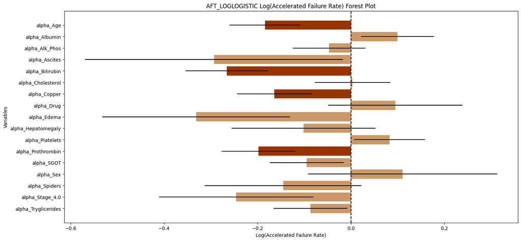

```python
##################################
# Plotting the log accelerated failure rate of the
# formulated Accelerated Failure Time model
# based on a Log-Logistic distribution
##################################
cirrhosis_survival_aft_loglogistic_summary = cirrhosis_survival_aft_loglogistic.summary
cirrhosis_survival_aft_loglogistic_summary_params = pd.DataFrame(cirrhosis_survival_aft_loglogistic.params_)
significant = cirrhosis_survival_aft_loglogistic_summary['p'] < 0.05
cirrhosis_survival_aft_loglogistic_summary_log_accelerated_failure_rate = (list(cirrhosis_survival_aft_loglogistic_summary_params.iloc[:,0].values))
plt.figure(figsize=(17, 8))
colors = ['#993300' if sig else '#CC9966' for sig in significant]

plt.barh([(index[0] + index[1]) for index in cirrhosis_survival_aft_loglogistic_summary_params.index[0:17]],
         cirrhosis_survival_aft_loglogistic_summary_log_accelerated_failure_rate[0:17],
         xerr=cirrhosis_survival_aft_loglogistic_summary['se(coef)'][0:17],
         color=colors)
plt.xlabel('Log(Accelerated Failure Rate)')
plt.ylabel('Variables')
plt.title('AFT_LOGLOGISTIC Log(Accelerated Failure Rate) Forest Plot')
plt.axvline(x=0, color='k', linestyle='--')
plt.gca().invert_yaxis()
plt.show()
```

```python
##################################
# Determining the number of
# significant predictors
##################################
cirrhosis_survival_aft_loglogistic_significant = sum(cirrhosis_survival_aft_loglogistic_summary['p'] < 0.05)
display(f"Number of Significant Predictors: {cirrhosis_survival_aft_loglogistic_significant-2}")
```

```
'Number of Significant Predictors: 4'
```

```python
##################################
# Formulating the Accelerated Failure Time model
# based on a Log-Logistic distribution
# using the significant predictors only
# and generating the summary
##################################
feature_subset = ['Bilirubin','Prothrombin','Age','Copper','N_Days','Status']
cirrhosis_survival_aft_loglogistic = LogLogisticAFTFitter(penalizer=0.30)
cirrhosis_survival_aft_loglogistic.fit(cirrhosis_survival_train_modeling[feature_subset], duration_col='N_Days', event_col='Status')
cirrhosis_survival_aft_loglogistic.print_summary()
```

| model | lifelines.LogLogisticAFTFitter |
| --- | --- |
| duration col | 'N_Days' |
| event col | 'Status' |
| penalizer | 0.3 |
| number of observations | 218 |
| number of events observed | 87 |
| log-likelihood | -792.48 |
| time fit was run | 2024-10-14 07:42:37 UTC |

|  |  | coef | exp(coef) | se(coef) | coef lower 95% | coef upper 95% | exp(coef) lower 95% | exp(coef) upper 95% | cmp to | z | p | -log2(p) |
| --- | --- | --- | --- | --- | --- | --- | --- | --- | --- | --- | --- | --- |
| alpha_ | Age | -0.20 | 0.82 | 0.07 | -0.35 | -0.06 | 0.71 | 0.94 | 0.00 | -2.80 | 0.01 | 7.60 |
|  | Bilirubin | -0.40 | 0.67 | 0.08 | -0.56 | -0.25 | 0.57 | 0.78 | 0.00 | -5.13 | <0.005 | 21.73 |
|  | Copper | -0.22 | 0.80 | 0.08 | -0.38 | -0.07 | 0.69 | 0.93 | 0.00 | -2.84 | <0.005 | 7.80 |
|  | Prothrombin | -0.29 | 0.75 | 0.08 | -0.44 | -0.14 | 0.65 | 0.87 | 0.00 | -3.84 | <0.005 | 13.00 |
|  | Intercept | 8.17 | 3530.45 | 0.10 | 7.98 | 8.36 | 2909.02 | 4284.63 | 0.00 | 82.70 | <0.005 | inf |
| beta_ | Intercept | 0.48 | 1.61 | 0.08 | 0.32 | 0.63 | 1.38 | 1.87 | 0.00 | 6.08 | <0.005 | 29.59 |

| Concordance | 0.84 |
| --- | --- |
| AIC | 1596.96 |
| log-likelihood ratio test | 73.33 on 4 df |
| -log2(p) of ll-ratio test | 47.66 |

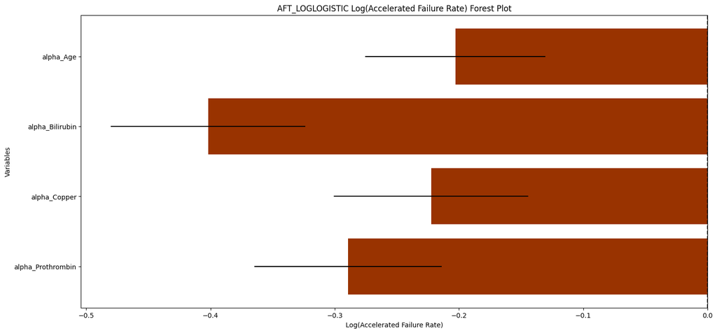

```python
##################################
# Plotting the log accelerated failure rate of the
# formulated Accelerated Failure Time model
# using the significant predictors only
# based on a Log-Logistic distribution
##################################
cirrhosis_survival_aft_loglogistic_summary = cirrhosis_survival_aft_loglogistic.summary
cirrhosis_survival_aft_loglogistic_summary_params = pd.DataFrame(cirrhosis_survival_aft_loglogistic.params_)
significant = cirrhosis_survival_aft_loglogistic_summary['p'] < 0.05
cirrhosis_survival_aft_loglogistic_summary_log_accelerated_failure_rate = (list(cirrhosis_survival_aft_loglogistic_summary_params.iloc[:,0].values))
plt.figure(figsize=(17, 8))
colors = ['#993300' if sig else '#CC9966' for sig in significant]

plt.barh([(index[0] + index[1]) for index in cirrhosis_survival_aft_loglogistic_summary_params.index[0:4]],
         cirrhosis_survival_aft_loglogistic_summary_log_accelerated_failure_rate[0:4],
         xerr=cirrhosis_survival_aft_loglogistic_summary['se(coef)'][0:4],
         color=colors)
plt.xlabel('Log(Accelerated Failure Rate)')
plt.ylabel('Variables')
plt.title('AFT_LOGLOGISTIC Log(Accelerated Failure Rate) Forest Plot')
plt.axvline(x=0, color='k', linestyle='--')
plt.gca().invert_yaxis()
plt.show()
```

```python
##################################
# Gathering the apparent model performance
# as baseline for evaluating overfitting
##################################
cirrhosis_survival_aft_loglogistic.fit(cirrhosis_survival_train_modeling[feature_subset], duration_col='N_Days', event_col='Status')
train_predictions = cirrhosis_survival_aft_loglogistic.predict_median(cirrhosis_survival_train_modeling)
cirrhosis_survival_aft_loglogistic_train_ci = concordance_index(cirrhosis_survival_train_modeling['N_Days'],
                                                            train_predictions,
                                                            cirrhosis_survival_train_modeling['Status'])
time_point = cirrhosis_survival_train_modeling['N_Days'].median()
cirrhosis_survival_aft_loglogistic_train_mae = mean_absolute_error(cirrhosis_survival_train_modeling['N_Days'], train_predictions)
cirrhosis_survival_aft_loglogistic_train_brier = brier_score_loss(cirrhosis_survival_train_modeling['Status'],
                                                              cirrhosis_survival_aft_loglogistic.predict_survival_function(cirrhosis_survival_train_modeling,
                                                                                                                       times=[time_point]).T[time_point])
display(f"Apparent Concordance Index: {cirrhosis_survival_aft_loglogistic_train_ci}")
display(f"Apparent MAE: {cirrhosis_survival_aft_loglogistic_train_mae}")
display(f"Apparent Brier Score: {cirrhosis_survival_aft_loglogistic_train_brier}")
```

```
'Apparent Concordance Index: 0.8383452535760728'
```

```
'Apparent MAE: 2727.4650862183294'
```

```
'Apparent Brier Score: 0.5095276225408752'
```

```python
##################################
# Performing 5-Fold Cross-Validation
# on the training data
##################################
kf = KFold(n_splits=5, shuffle=True, random_state=88888888)
ci_scores = []
mae_scores = []
brier_scores = []

for train_index, val_index in kf.split(cirrhosis_survival_train_modeling):
    df_train_fold = cirrhosis_survival_train_modeling.iloc[train_index]
    df_val_fold = cirrhosis_survival_train_modeling.iloc[val_index]

    cirrhosis_survival_aft_loglogistic.fit(df_train_fold[feature_subset], duration_col='N_Days', event_col='Status')
    val_predictions = cirrhosis_survival_aft_loglogistic.predict_median(df_val_fold)
    time_point = df_val_fold['N_Days'].median()
    ci = concordance_index(df_val_fold['N_Days'], val_predictions, df_val_fold['Status'])
    mae = mean_absolute_error(df_val_fold['N_Days'], val_predictions)
    brier = brier_score_loss(df_val_fold['Status'],
                             cirrhosis_survival_aft_loglogistic.predict_survival_function(df_val_fold,
                                                                                      times=[time_point]).T[time_point])
    ci_scores.append(ci)
    mae_scores.append(mae)
    brier_scores.append(brier)

cirrhosis_survival_aft_loglogistic_cv_ci_mean = np.mean(ci_scores)
cirrhosis_survival_aft_loglogistic_cv_ci_std = np.std(ci_scores)
cirrhosis_survival_aft_loglogistic_cv_mae_mean = np.mean(mae_scores)
cirrhosis_survival_aft_loglogistic_cv_brier_mean = np.mean(brier_scores)

display(f"Cross-Validated Concordance Index: {cirrhosis_survival_aft_loglogistic_cv_ci_mean}")
display(f"Cross-Validated MAE: {cirrhosis_survival_aft_loglogistic_cv_mae_mean}")
display(f"Cross-Validated Brier Score: {cirrhosis_survival_aft_loglogistic_cv_brier_mean}")
```

```
'Cross-Validated Concordance Index: 0.8301281045334907'
```

```
'Cross-Validated MAE: 2711.6604860313473'
```

```
'Cross-Validated Brier Score: 0.5065381245204559'
```

```python
##################################
# Evaluating the model performance
# on test data
##################################
test_predictions = cirrhosis_survival_aft_loglogistic.predict_median(cirrhosis_survival_test_modeling)
cirrhosis_survival_aft_loglogistic_test_ci = concordance_index(cirrhosis_survival_test_modeling['N_Days'],
                                                           test_predictions,
                                                           cirrhosis_survival_test_modeling['Status'])
time_point = cirrhosis_survival_test_modeling['N_Days'].median()
cirrhosis_survival_aft_loglogistic_test_mae = mean_absolute_error(cirrhosis_survival_test_modeling['N_Days'], test_predictions)
cirrhosis_survival_aft_loglogistic_test_brier = brier_score_loss(cirrhosis_survival_test_modeling['Status'],
                                                              cirrhosis_survival_aft_loglogistic.predict_survival_function(cirrhosis_survival_test_modeling,
                                                                                                                       times=[time_point]).T[time_point])
display(f"Apparent Concordance Index: {cirrhosis_survival_aft_loglogistic_test_ci}")
display(f"Apparent MAE: {cirrhosis_survival_aft_loglogistic_test_mae}")
display(f"Apparent Brier Score: {cirrhosis_survival_aft_loglogistic_test_brier}")
```

```
'Apparent Concordance Index: 0.8625850340136054'
```

```
'Apparent MAE: 2189.9323142397443'
```

```
'Apparent Brier Score: 0.5332955064077313'
```

```python
##################################
# Gathering the model performance metrics
# from training, cross-validation and test
##################################
aft_loglogistic_set = pd.DataFrame(["Train","Cross-Validation","Test"]*3)
aft_loglogistic_metric = pd.DataFrame((["Concordance.Index"]*3) + (["MAE"]*3) + (["Brier.Score"]*3))
aft_loglogistic_metric_values = pd.DataFrame([cirrhosis_survival_aft_loglogistic_train_ci,
                                           cirrhosis_survival_aft_loglogistic_cv_ci_mean,
                                           cirrhosis_survival_aft_loglogistic_test_ci,
                                           cirrhosis_survival_aft_loglogistic_train_mae,
                                           cirrhosis_survival_aft_loglogistic_cv_mae_mean,
                                           cirrhosis_survival_aft_loglogistic_test_mae,
                                           cirrhosis_survival_aft_loglogistic_train_brier,
                                           cirrhosis_survival_aft_loglogistic_cv_brier_mean,
                                           cirrhosis_survival_aft_loglogistic_test_brier])
aft_loglogistic_method = pd.DataFrame(["AFT_LOGLOGISTIC"]*9)
aft_loglogistic_summary = pd.concat([aft_loglogistic_set,
                                       aft_loglogistic_metric,
                                       aft_loglogistic_metric_values,
                                       aft_loglogistic_method],
                                      axis=1)
aft_loglogistic_summary.columns = ['Set', 'Metric', 'Value', 'Method']
aft_loglogistic_summary.reset_index(inplace=True, drop=True)
display(aft_loglogistic_summary)
```

|  | Set | Metric | Value | Method |
| --- | --- | --- | --- | --- |
| 0 | Train | Concordance.Index | 0.838345 | AFT_LOGLOGISTIC |
| 1 | Cross-Validation | Concordance.Index | 0.830128 | AFT_LOGLOGISTIC |
| 2 | Test | Concordance.Index | 0.862585 | AFT_LOGLOGISTIC |
| 3 | Train | MAE | 2727.465086 | AFT_LOGLOGISTIC |
| 4 | Cross-Validation | MAE | 2711.660486 | AFT_LOGLOGISTIC |
| 5 | Test | MAE | 2189.932314 | AFT_LOGLOGISTIC |
| 6 | Train | Brier.Score | 0.509528 | AFT_LOGLOGISTIC |
| 7 | Cross-Validation | Brier.Score | 0.506538 | AFT_LOGLOGISTIC |
| 8 | Test | Brier.Score | 0.533296 | AFT_LOGLOGISTIC |

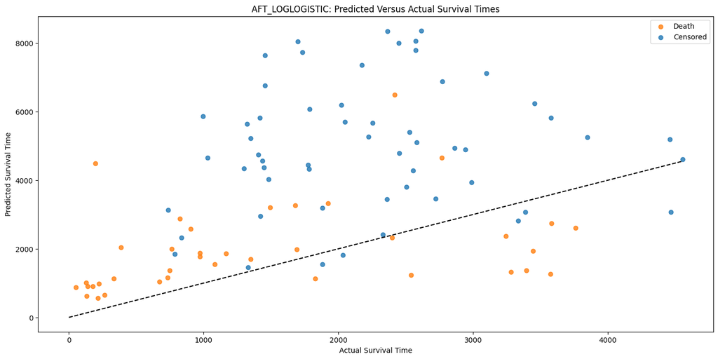

```python
##################################
# Evaluating the predicted
# and actual survival times
##################################
predicted_survival_times = cirrhosis_survival_aft_loglogistic.predict_median(cirrhosis_survival_test_modeling)
fig, ax = plt.subplots(figsize=(17, 8))
for status, color, label in zip([True, False], ['#FF7F0E','#1F77B4'], ['Death', 'Censored']):
    subset = cirrhosis_survival_test_modeling[cirrhosis_survival_test_modeling['Status'] == status]
    ax.scatter(subset['N_Days'], predicted_survival_times.iloc[subset.index], c=color, label=label, alpha=0.8)
ax.set_xlabel('Actual Survival Time')
ax.set_ylabel('Predicted Survival Time')
ax.set_title('AFT_LOGLOGISTIC: Predicted Versus Actual Survival Times')
ax.legend()
plt.plot([0, cirrhosis_survival_test_modeling['N_Days'].max()],
         [0, cirrhosis_survival_test_modeling['N_Days'].max()],
         color='black', linestyle='--')
plt.show()
```

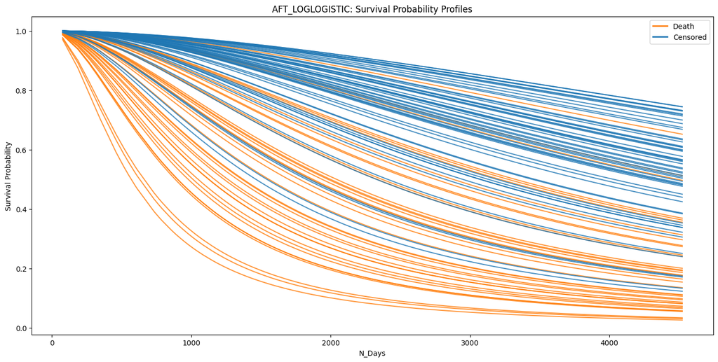

```python
##################################
# Plotting the individual
# survival probability profiles
##################################
plt.figure(figsize=(17, 8))
for status, color, label in zip([True, False], ['#FF7F0E','#1F77B4'], ['Death', 'Censored']):
    subset = cirrhosis_survival_test_modeling[cirrhosis_survival_test_modeling['Status'] == status]
    for i, row in subset.iterrows():
        survival_function = cirrhosis_survival_aft_loglogistic.predict_survival_function(row)
        plt.plot(survival_function.index, survival_function.iloc[:, 0], c=color, alpha=0.8)
plt.title('AFT_LOGLOGISTIC: Survival Probability Profiles')
plt.xlabel('N_Days')
plt.ylabel('Survival Probability')
death_patch = plt.Line2D([0], [0], color='#FF7F0E', lw=2, label='Death')
censored_patch = plt.Line2D([0], [0], color='#1F77B4', lw=2, label='Censored')
plt.legend(handles=[death_patch, censored_patch])
plt.show()
```

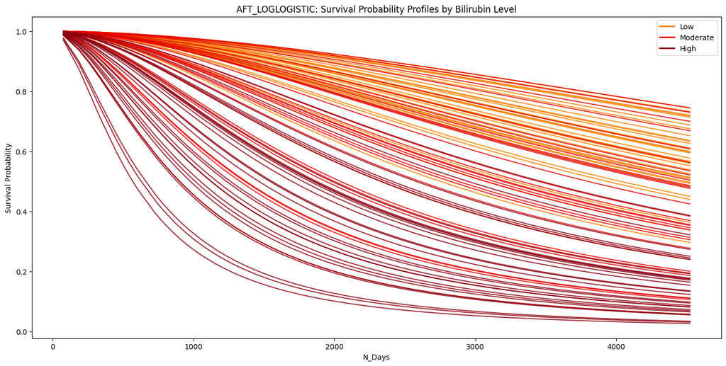

```python
##################################
# Plotting the individual
# survival probability profiles
# for the discretized Bilirubin predictor
##################################
cirrhosis_survival_test_modeling['Bilirubin_Level'] = pd.qcut(cirrhosis_survival_test_modeling['Bilirubin'], 3, labels=['Low','Moderate','High'])
plt.figure(figsize=(17, 8))
for bilirubin_level, color, label in zip(['Low', 'Moderate', 'High'], ['#FA8000','#E50000', '#8C000F'], ['Low', 'Moderate', 'High']):
    subset = cirrhosis_survival_test_modeling[cirrhosis_survival_test_modeling['Bilirubin_Level'] == bilirubin_level]
    for i, row in subset.iterrows():
        survival_function = cirrhosis_survival_aft_loglogistic.predict_survival_function(row)
        plt.plot(survival_function.index, survival_function.iloc[:, 0], c=color, alpha=0.8)
plt.title('AFT_LOGLOGISTIC: Survival Probability Profiles by Bilirubin Level')
plt.xlabel('N_Days')
plt.ylabel('Survival Probability')
low_patch = plt.Line2D([0], [0], color='#FA8000', lw=2, label='Low')
moderate_patch = plt.Line2D([0], [0], color='#E50000', lw=2, label='Moderate')
high_patch = plt.Line2D([0], [0], color='#8C000F', lw=2, label='High')
plt.legend(handles=[low_patch, moderate_patch, high_patch])
plt.show()
```

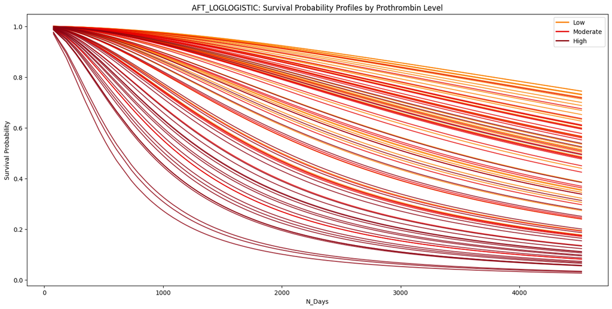

```python
##################################
# Plotting the individual
# survival probability profiles
# for the discretized Prothrombin predictor
##################################
cirrhosis_survival_test_modeling['Prothrombin_Level'] = pd.qcut(cirrhosis_survival_test_modeling['Prothrombin'], 3, labels=['Low','Moderate','High'])
plt.figure(figsize=(17, 8))
for prothrombin_level, color, label in zip(['Low', 'Moderate', 'High'], ['#FA8000','#E50000', '#8C000F'], ['Low', 'Moderate', 'High']):
    subset = cirrhosis_survival_test_modeling[cirrhosis_survival_test_modeling['Prothrombin_Level'] == prothrombin_level]
    for i, row in subset.iterrows():
        survival_function = cirrhosis_survival_aft_loglogistic.predict_survival_function(row)
        plt.plot(survival_function.index, survival_function.iloc[:, 0], c=color, alpha=0.8)
plt.title('AFT_LOGLOGISTIC: Survival Probability Profiles by Prothrombin Level')
plt.xlabel('N_Days')
plt.ylabel('Survival Probability')
low_patch = plt.Line2D([0], [0], color='#FA8000', lw=2, label='Low')
moderate_patch = plt.Line2D([0], [0], color='#E50000', lw=2, label='Moderate')
high_patch = plt.Line2D([0], [0], color='#8C000F', lw=2, label='High')
plt.legend(handles=[low_patch, moderate_patch, high_patch])
plt.show()
```

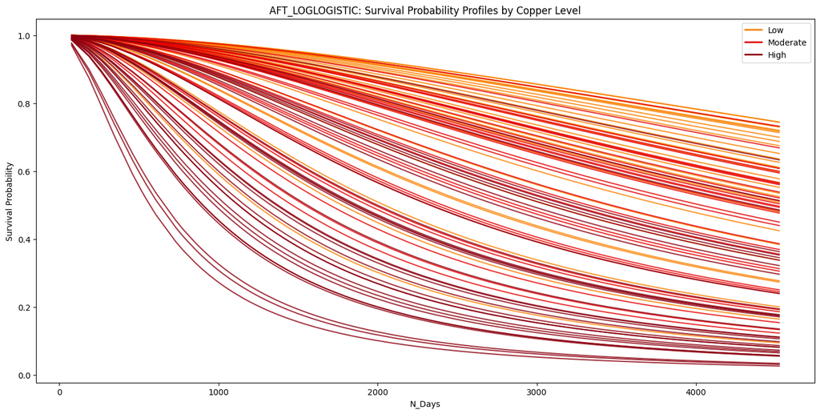

```python
##################################
# Plotting the individual
# survival probability profiles
# for the discretized Copper predictor
##################################
cirrhosis_survival_test_modeling['Copper_Level'] = pd.qcut(cirrhosis_survival_test_modeling['Copper'], 3, labels=['Low','Moderate','High'])
plt.figure(figsize=(17, 8))
for copper_level, color, label in zip(['Low', 'Moderate', 'High'], ['#FA8000','#E50000', '#8C000F'], ['Low', 'Moderate', 'High']):
    subset = cirrhosis_survival_test_modeling[cirrhosis_survival_test_modeling['Copper_Level'] == copper_level]
    for i, row in subset.iterrows():
        survival_function = cirrhosis_survival_aft_loglogistic.predict_survival_function(row)
        plt.plot(survival_function.index, survival_function.iloc[:, 0], c=color, alpha=0.8)
plt.title('AFT_LOGLOGISTIC: Survival Probability Profiles by Copper Level')
plt.xlabel('N_Days')
plt.ylabel('Survival Probability')
low_patch = plt.Line2D([0], [0], color='#FA8000', lw=2, label='Low')
moderate_patch = plt.Line2D([0], [0], color='#E50000', lw=2, label='Moderate')
high_patch = plt.Line2D([0], [0], color='#8C000F', lw=2, label='High')
plt.legend(handles=[low_patch, moderate_patch, high_patch])
plt.show()
```

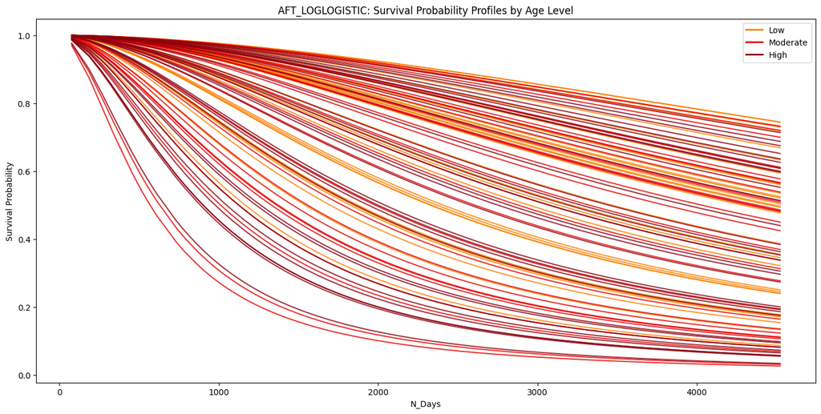

```python
##################################
# Plotting the individual
# survival probability profiles
# for the discretized Age predictor
##################################
cirrhosis_survival_test_modeling['Age_Level'] = pd.qcut(cirrhosis_survival_test_modeling['Age'], 3, labels=['Low','Moderate','High'])
plt.figure(figsize=(17, 8))
for age_level, color, label in zip(['Low', 'Moderate', 'High'], ['#FA8000','#E50000', '#8C000F'], ['Low', 'Moderate', 'High']):
    subset = cirrhosis_survival_test_modeling[cirrhosis_survival_test_modeling['Age_Level'] == age_level]
    for i, row in subset.iterrows():
        survival_function = cirrhosis_survival_aft_loglogistic.predict_survival_function(row)
        plt.plot(survival_function.index, survival_function.iloc[:, 0], c=color, alpha=0.8)
plt.title('AFT_LOGLOGISTIC: Survival Probability Profiles by Age Level')
plt.xlabel('N_Days')
plt.ylabel('Survival Probability')
low_patch = plt.Line2D([0], [0], color='#FA8000', lw=2, label='Low')
moderate_patch = plt.Line2D([0], [0], color='#E50000', lw=2, label='Moderate')
high_patch = plt.Line2D([0], [0], color='#8C000F', lw=2, label='High')
plt.legend(handles=[low_patch, moderate_patch, high_patch])
plt.show()
```

```python
##################################
# Defining a prediction function
# for SHAP value estimation
##################################
def aft_predict(fitter, df):
    return fitter.predict_expectation(df)

##################################
# Creating the explainer object
##################################
explainer_loglogistic = shap.Explainer(lambda x: aft_predict(cirrhosis_survival_aft_loglogistic,
                                                         pd.DataFrame(x, columns=cirrhosis_survival_train_modeling.columns[2:])),
                                   cirrhosis_survival_train_modeling.iloc[:, 2:])
shap_values_loglogistic = explainer_loglogistic(cirrhosis_survival_train_modeling.iloc[:, 2:])
```

```
PermutationExplainer explainer: 219it [00:23,  5.45it/s]
```

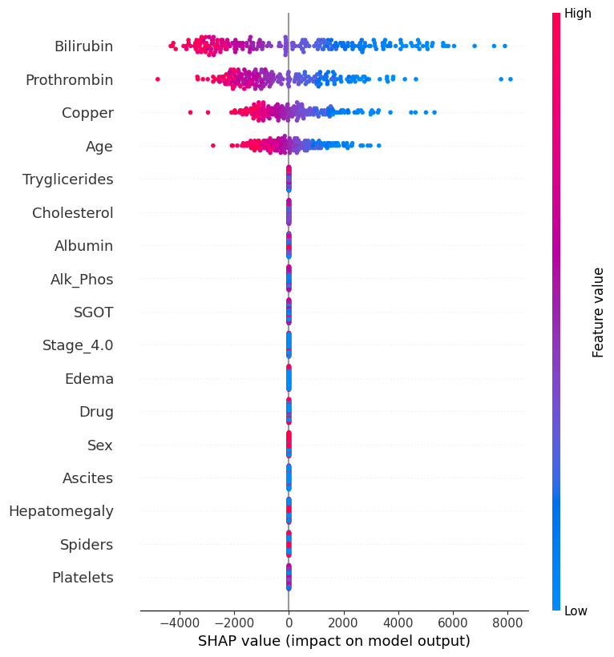

```python
##################################
# Plotting the SHAP summary plot
##################################
shap.summary_plot(shap_values_loglogistic,
                  cirrhosis_survival_train_modeling.iloc[:, 2:])
```